# 100_Statistical_Tests_in_R

### Test 2 Spearman Rank Correlation Test

When to use this test?

- To assess the null hypothesis of zero correlation between two variables.
- Ordinal or ranked data
- Data is continuous and unreasonable to assume the variables are normally distributed
- Linear relationship

In this test, we will continue to use iris dataset to compare and illustrate the relationship between lengths of sepals and petals.

```r
cor.test(iris$Sepal.Length,iris$Petal.Length, method = "spearman", alternative = "two.sided")
```

```
##
##  Spearman's rank correlation rho
##
## data:  iris$Sepal.Length and iris$Petal.Length
## S = 66429, p-value < 2.2e-16
## alternative hypothesis: true rho is not equal to 0
## sample estimates:
##       rho
## 0.8818981
```

The correlation between x (length of sepals) and y (length of petal) is 0.882. The p-value is smaller than 0.05, we reject the null hypothesis of zero correlation. In the spearman test, there is no confidence interval normally. Spearman correlation uses rank-based calculations rather than the raw data values, making the sampling distribution more complex for computing confidence intervals using standard parametrix methods.

### Test 3 Kendall’s Tau Correlation Coefficient Test

When to use this test?

- a paired random sample of ordinal or ranked data
- data is continuous and it is unreasonable to the variables are normally distributed
- linear relationship

We will use a new dataset mtcars to illustrate the Tau correlation coefficient test:

| [, 1] | mpg | Miles/(US) gallon |
| --- | --- | --- |
| [, 2] | cyl | Number of cylinders |
| [, 3] | disp | Displacement (cu.in.) |
| [, 4] | hp | Gross horsepower |
| [, 5] | drat | Rear axle ratio |
| [, 6] | wt | Weight (1000 lbs) |
| [, 7] | qsec | 1/4 mile time |
| [, 8] | vs | Engine (0 = V-shaped, 1 = straight) |
| [, 9] | am | Transmission (0 = automatic, 1 = manual) |
| [,10] | gear | Number of forward gears |

```r
str(mtcars)
```

```
## 'data.frame':    32 obs. of  11 variables:
##  $ mpg : num  21 21 22.8 21.4 18.7 18.1 14.3 24.4 22.8 19.2 ...
##  $ cyl : num  6 6 4 6 8 6 8 4 4 6 ...
##  $ disp: num  160 160 108 258 360 ...
##  $ hp  : num  110 110 93 110 175 105 245 62 95 123 ...
##  $ drat: num  3.9 3.9 3.85 3.08 3.15 2.76 3.21 3.69 3.92 3.92 ...
##  $ wt  : num  2.62 2.88 2.32 3.21 3.44 ...
##  $ qsec: num  16.5 17 18.6 19.4 17 ...
##  $ vs  : num  0 0 1 1 0 1 0 1 1 1 ...
##  $ am  : num  1 1 1 0 0 0 0 0 0 0 ...
##  $ gear: num  4 4 4 3 3 3 3 4 4 4 ...
##  $ carb: num  4 4 1 1 2 1 4 2 2 4 ...
```

```r
summary(mtcars)
```

```
##       mpg             cyl             disp             hp
##  Min.   :10.40   Min.   :4.000   Min.   : 71.1   Min.   : 52.0
##  1st Qu.:15.43   1st Qu.:4.000   1st Qu.:120.8   1st Qu.: 96.5
##  Median :19.20   Median :6.000   Median :196.3   Median :123.0
##  Mean   :20.09   Mean   :6.188   Mean   :230.7   Mean   :146.7
##  3rd Qu.:22.80   3rd Qu.:8.000   3rd Qu.:326.0   3rd Qu.:180.0
##  Max.   :33.90   Max.   :8.000   Max.   :472.0   Max.   :335.0
##       drat             wt             qsec             vs
##  Min.   :2.760   Min.   :1.513   Min.   :14.50   Min.   :0.0000
##  1st Qu.:3.080   1st Qu.:2.581   1st Qu.:16.89   1st Qu.:0.0000
##  Median :3.695   Median :3.325   Median :17.71   Median :0.0000
##  Mean   :3.597   Mean   :3.217   Mean   :17.85   Mean   :0.4375
##  3rd Qu.:3.920   3rd Qu.:3.610   3rd Qu.:18.90   3rd Qu.:1.0000
##  Max.   :4.930   Max.   :5.424   Max.   :22.90   Max.   :1.0000
##        am              gear            carb
##  Min.   :0.0000   Min.   :3.000   Min.   :1.000
##  1st Qu.:0.0000   1st Qu.:3.000   1st Qu.:2.000
##  Median :0.0000   Median :4.000   Median :2.000
##  Mean   :0.4062   Mean   :3.688   Mean   :2.812
##  3rd Qu.:1.0000   3rd Qu.:4.000   3rd Qu.:4.000
##  Max.   :1.0000   Max.   :5.000   Max.   :8.000
```

```r
cor.test(mtcars$hp,mtcars$wt, method="kendal", alternative = "two.sided")
```

```
##
##  Kendall's rank correlation tau
##
## data:  mtcars$hp and mtcars$wt
## z = 4.845, p-value = 1.266e-06
## alternative hypothesis: true tau is not equal to 0
## sample estimates:
##       tau
## 0.6113081
```

The correlation between x (hp) and y (wt) is 0.611. The p-value is significant smaller than the critical value 0.05. Therefore, we reject the null hypothesis.

### Test 4 Z-Test of the Difference Between Independent Correlations

When to use this test?

- correlation coefficients calculated from independent samples
- data are assumed to be bivariate normal
- sample size may be different

Z-test is less common than Pearson or Spearman correlation. It actually examines whether the correlation coefficients from two or more samples with different sample size is correlated or not.

```r
cor_setosa <- cor(iris$Sepal.Length[iris$Species == "setosa"], iris$Petal.Length[iris$Species == "setosa"], method = "pearson")
cor_versicolor <- cor(iris$Sepal.Width[iris$Species == "versicolor"], iris$Petal.Width[iris$Species == "versicolor"], method = "pearson")
n_setosa <- sum(iris$Species == "setosa")
n_versicolor <- sum(iris$Species == "versicolor")
```

Now we will use paired.r() to calculate the Z-test.

```r
z_test_cor_setosa_versicolor <- paired.r(cor_setosa, cor_versicolor, NULL, n_setosa, n_versicolor, twotailed=TRUE)
z_test_cor_setosa_versicolor$test
```

```
## [1] "test of difference between two independent correlations"
```

```r
z_test_cor_setosa_versicolor$z
```

```
## [1] 2.550422
```

```r
z_test_cor_setosa_versicolor$p
```

```
## [1] 0.01075925
```

The p-value is less than the critical value 0.05. Therefore we can reject the null hypothesis.

### Test 5 Difference Between Two Overlapping Correlation Coefficients

When to use this test?

- Compare the null hypothesis of zero correlation between one pair of variables and another pair of variables shared with an overlapping variable
- aim to select the better indicator of two available predictors (x and y) for a dependent variable z
- data are assumed to be normally distributed
- referred to as Steiger’s t-test, Meng’s t-test, Rosenthal & Rubin’s t-test or Williams test

We will use mtcars to evaluate the relationships between the correlation of wt (weights) and mpg (miles per gallon) and the correlation of hp (horsepower) and mpg and figure out whether wt or hp is a better indicator of mpg.

We will need compOverlapCorr and psych packages for this test.

```r
library(compOverlapCorr)
library(psych)
```

```r
cor_mpg_wt <- cor(mtcars$mpg,mtcars$wt, method = "pearson")
cor_mpg_hp <- cor(mtcars$mpg, mtcars$hp, method = "pearson")
cor_hp_wt <- cor(mtcars$hp, mtcars$wt, method = "pearson")
compOverlapCorr(length(mtcars$mpg), cor_mpg_wt, cor_mpg_hp, cor_hp_wt)
```

```
## [1] -1.3303850  0.1833915
```

The first number is the result of t-test and the second number is p-value. The p-value is greater than the critical value 0.05. Therefore, we can not reject the null hypothesis.

We can also use psych package to calculate this correlation.

```r
paired.r(cor_mpg_wt, cor_mpg_hp, cor_hp_wt, length(mtcars$mpg), twotailed = TRUE)
```

```
## Call: paired.r(xy = cor_mpg_wt, xz = cor_mpg_hp, yz = cor_hp_wt, n = length(mtcars$mpg),
##     twotailed = TRUE)
## [1] "test of difference between two correlated  correlations"
## t = -1.35  With probability =  0.19
```

We can see the same results from both two packages. As the package {compOverlapCorr} is no longer maintained, we should use {psych} to measure this test.

### Test 6 Difference Between Two Non-Overlapping Dependent Correlation Coefficients

Question the test adrreses:

**Is the correlation between two variables (A and B) significantly different from the correlation between two other variables (C and D), when all four variables were measured in the same group.**

When to use this test?

- To assess the difference between one pair of variables and a second non-overlapping pair of variables.
- Non-overlapping could be related items in different times
- Data are assumed to be normally distributed

Usually, this method aims to discuss the difference in correlation between two variables in two different times for serial analysis. Here, we will discuss the basic mode of this test, two independent sets of variables in the dataset mtcars.

For the cars in this dataset, is the relationship between engine power (hp and disp) significantly different with the relationship between performance (mpg and wt)

```r
library("psych")
```

```r
cor_hp_disp <- cor(mtcars$hp, mtcars$disp, method = "pearson")
cor_mpg_wt <- cor(mtcars$mpg, mtcars$wt, method ="pearson")
#we also need the cross relationships between these variables

cor_hp_wt <- cor(mtcars$hp, mtcars$wt, method = "pearson")
cor_mpg_disp <- cor(mtcars$mpg, mtcars$disp, method = "pearson")
cor_mpg_hp <- cor(mtcars$mpg, mtcars$hp, method = "pearson")
cor_disp_wt <- cor(mtcars$disp, mtcars$wt, method = "pearson")
r.test(length(mtcars$mpg), r12 = cor_hp_wt,r34 =  cor_mpg_wt,r23 = cor_mpg_disp, r13 = cor_hp_wt, r14 = cor_hp_wt, r24 = cor_mpg_disp, twotailed = TRUE)
```

```
## Correlation tests
## Call:r.test(n = length(mtcars$mpg), r12 = cor_hp_wt, r34 = cor_mpg_wt,
##     r23 = cor_mpg_disp, r13 = cor_hp_wt, r14 = cor_hp_wt, r24 = cor_mpg_disp,
##     twotailed = TRUE)
## Test of difference between two dependent correlations
##  z value 5.52    with probability  0
```

### Test 7 Bartlett’s Test of Sphericity

Question the test adrreses:

**Are these variables essentially independent of each other?**

When to use this test?

- check the correlation matrix is different from identity matrix
- identity matrix means all variables in this matrix are uncorrelated
- to check whether data is suitable for factor analysis (FA)

For researcher, if we want to conduct factor analysis for our variables, it is important that we should reject the null hypothesis of Bartlett’s test that there is no difference between our variable matrix and identity matrix. Only when variables are correlated with each other, we can continue to do factor analysis.

For this test, we will use iris dataset to test the variable matrix among `Sepal.Length`, `Sepal.Width`, `Petal.Length`, `Petal.Width`.

```r
library("psych")
```

```r
matrix_data <- iris[, 1:4]
cortest.bartlett(matrix_data)
```

```
## $chisq
## [1] 706.9592
##
## $p.value
## [1] 1.92268e-149
##
## $df
## [1] 6
```

According to the result, we can find the p-value is smaller than the critical value 0.05. Therefore, we should reject the null hypothesis that our matrix is the identity matrix. We can argue that there are internal correlations between our matrix among `Sepal.Length`, `Sepal,Width`, `Petal.Length`, and `Petal.Width`.

### Test 8 The Jennrich Test of the Equality of Two Matrices

Question the test adrreses:

**Is the fundamental pattern of correlations at A the same as the pattern at B?**

To use this test:

- Two independent samples or subsamples
- The same set of variables measured for both groups
- The data are assumed to be normally distributed

In this test, we will use the `EuStockMarkets` dataset, which is a built-in dataset in R, measuring the daily closing prices for 4 major EU stock indices from 1991-1998.

We will examine the correlation pattern between the DAX, SMI, CAC, and FTSE indices different in the first half of the time period and the second half of the time period.

```r
library("psych")
sample1 <- EuStockMarkets[1:900, ]
sample2 <- EuStockMarkets[961:1860, ]
```

```r
cortest.jennrich(sample1,sample2)
```

```
## $chi2
## [1] -719.9148
##
## $prob
## [1] 1
```

According to the result, we can find the p-value is larger than the critical value 0.05. Therefore, we can not reject the null hypothesis that the correlation patterns of these two samples are statistically the same. The overall pattern of correlation between the major EU stock indices did not significantly change between the two time periods.

### Test 9 The Granger Causality Test

Question the test adrreses:

**Is one time series useful in forecasting another time series?**

To use this test:

- at least two time series data
- stationary data: all properties of data are constant over time such as mean, variance and autocorrelation
- data are assumed to be ordered chronologically

In this test, we will continue to use the time series data `EuStockMarters` with the `diff()` function to create a suitable dataset for this analysis. We will test these relationships:

- Dose DAX Granger-cause CAC?
- Does DAX Granger-cause FTSE?
- Does SMI Granger-cause CAC?
- Does SMI Granger-cause FTSE?

```r
data("EuStockMarkets")
dax_diff <- diff(EuStockMarkets[,"DAX"])
smi_diff <- diff(EuStockMarkets[,"SMI"])
cac_diff <- diff(EuStockMarkets[,"CAC"])
ftse_diff <- diff(EuStockMarkets[,"FTSE"])
```

```r
library(lmtest)
grangertest(cac_diff ~ dax_diff, order = 3)
```

|  | Res.Df | Df | F | Pr(>F) |
| --- | --- | --- | --- | --- |
| 1 | 1849 | NA | NA | NA |
| 2 | 1852 | -3 | 0.8165198 | 0.4846519 |

According to the result, we can find that the p-value is larger than the critical value 0.05.Therefore, we can not reject the null hypothesis that DAX does not Granger-cause CAC. Similarly, we can continue to finish the rest of tests

```r
grangertest(ftse_diff ~ dax_diff, order = 3)
```

|  | Res.Df | Df | F | Pr(>F) |
| --- | --- | --- | --- | --- |
| 1 | 1849 | NA | NA | NA |
| 2 | 1852 | -3 | 1.309328 | 0.2696909 |

```r
grangertest(cac_diff ~ smi_diff, order = 3)
```

|  | Res.Df | Df | F | Pr(>F) |
| --- | --- | --- | --- | --- |
| 1 | 1849 | NA | NA | NA |
| 2 | 1852 | -3 | 3.946589 | 0.008081108 |

```r
grangertest(ftse_diff ~ smi_diff, order = 3)
```

|  | Res.Df | Df | F | Pr(>F) |
| --- | --- | --- | --- | --- |
| 1 | 1849 | NA | NA | NA |
| 2 | 1852 | -3 | 5.59712 | 0.0008068707 |

According to the test, we can see that the latter two p-values are significant smaller than the critical value 0.05. Therefore, we can reject the null hypothesises. SMI Granger-causes the FTSE and CAC.

We can also visualise these results to “see” the relationships. We will use ggplot 2 and zoo packages.

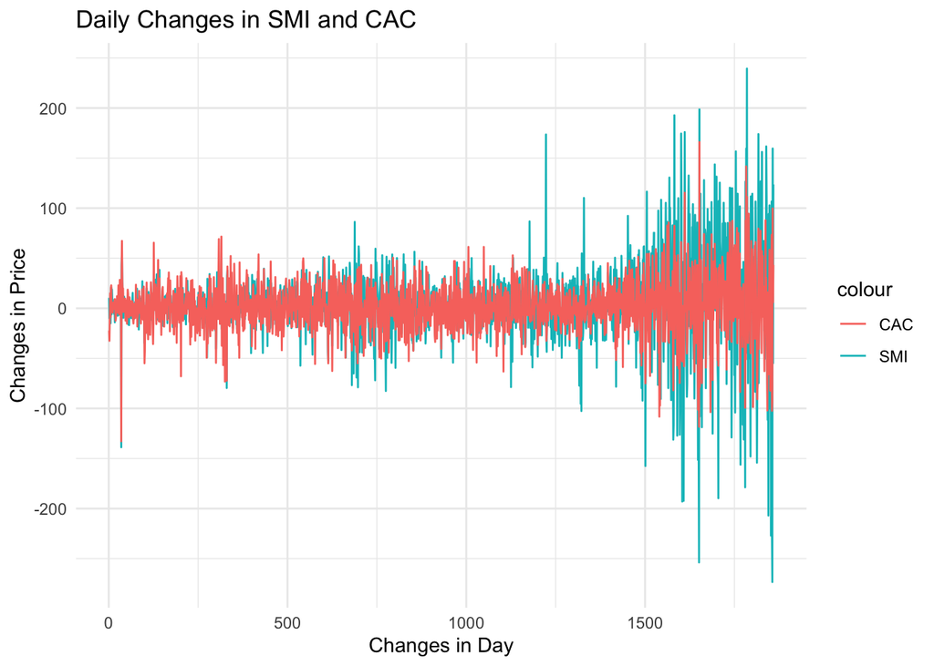

```r
library(ggplot2)
library(zoo)

plot_data <- data.frame(
  Date = 1:length(dax_diff),
  SMI = as.numeric(smi_diff),
  CAC = as.numeric(cac_diff),
  FTSE = as.numeric(ftse_diff)
)

ggplot(plot_data, aes(x=Date)) +
  geom_line(aes(y=SMI, color = "SMI")) +
  geom_line(aes(y=CAC, color="CAC")) +
  labs(title = "Daily Changes in SMI and CAC", y = "Changes in Price", x="Changes in Day") +
  theme_minimal()
```

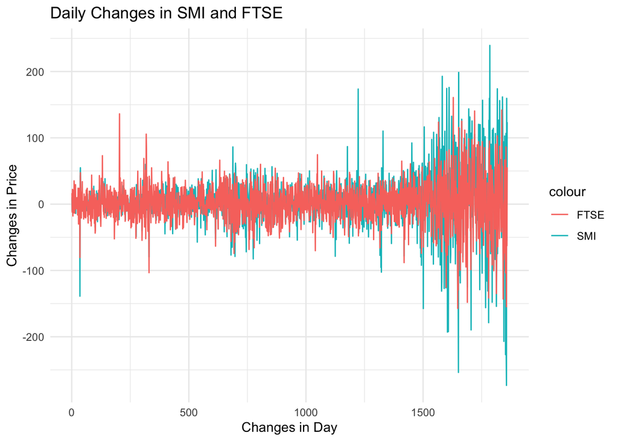

```r
ggplot(plot_data, aes(x=Date)) +
  geom_line(aes(y=SMI, color = "SMI")) +
  geom_line(aes(y=FTSE, color="FTSE")) +
  labs(title = "Daily Changes in SMI and FTSE", y = "Changes in Price", x="Changes in Day") +
  theme_minimal()
```

### Test 10 Durbin-Watson Autocorrelation Test

Question the test adrreses:

**Is there serial correlation in the sample?**

To use this test:

- whether residuals (error terms) from a regression model are independent
- residuals are stationary and normally distribution with zero mean

If residuals are not independent, the model will have incorrect standard errors, misleading p-values and false positives. The error from one observation provides information about the error in the next observation, which violates the assumption of linear regression.

For this test, we will use `cars` to build a simple linear regression model, and test the relationship between `dist ~ speed`.

```r
data("cars")

car_model <- lm(dist ~ speed, data = cars)
```

```r
library("car")
durbinWatsonTest(car_model)
```

```
##  lag Autocorrelation D-W Statistic p-value
##    1       0.1604322      1.676225   0.188
##  Alternative hypothesis: rho != 0
```

According to the result, we can see that the p-value is larger than the critical value 0.05. Therefore, we can not reject the null hypothesis that there is no autocorrelations in this model.

To visualise the residuals, we can plot each residual against the one that came before it (the lagged value). If there is no autocorrelation, we should see the random dot cloud with no observable pattern.

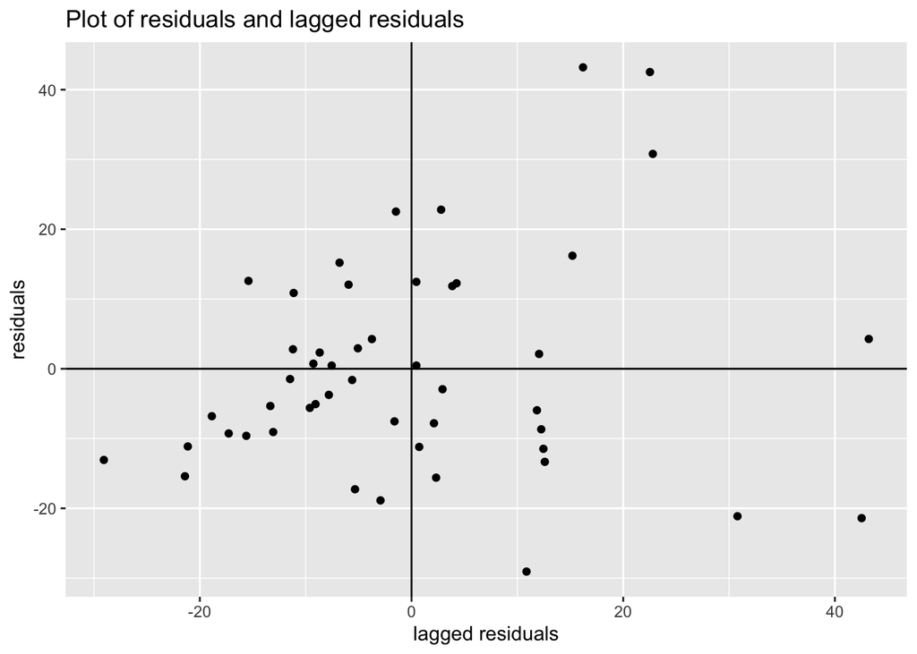

```r
res <- residuals(car_model)

residual_data <- data_frame(
  Residuals = res[-1],
  Lagged_Residuals = res[-length(res)]
)

ggplot(residual_data, aes(x = Lagged_Residuals, y= Residuals)) +
  geom_point() +
  geom_hline(yintercept = 0) +
  geom_vline(xintercept = 0) +
  labs(title = "Plot of residuals and lagged residuals", x = "lagged residuals", y = "residuals")
```

### Test 11 Breusch-Godfrey Autocorrelation Test

Question the test adrreses:

**Is there serial correlation in the sample?**

To use this test:

- included lagged values in the model
- residuals are assumed to be stationary and normally distribution with zero mean
- powerful and general than Durbin-Watson Autocorrelation test

This test is used when there is lagged values of dependent variables in the model, which can not use the Durbin-Watson test. For example, the growth of population in one city or the stock prices in the market. We will use `EuStockMarkets` to examine this test. We will examine the daily changes of DAX.

```r
library(lmtest)
dax_df <- data.frame(DAX_change = as.numeric(dax_diff))

dax_df <- dax_df %>%
  mutate(DAX_change_lag1 = lag(DAX_change, 1))

dynamic_model <- lm(DAX_change ~ DAX_change_lag1, data = dax_df)
```

```r
bgtest(dynamic_model, order = 3)
```

```
##
##  Breusch-Godfrey test for serial correlation of order up to 3
##
## data:  dynamic_model
## LM test = 0.65409, df = 3, p-value = 0.8839
```

According to this result, the p-value is larger than the critical value 0.05. Therefore, we can not reject the null hypothesis that there is no lagged value in the dependent variables.

## Test 12 T-test

### Test 12 One-Sample t-test For a Hypothesised Mean

Question the test adrreses:

**Is the mean of a sample significantly different from a hypothesised mean?**

To use this test:

- data is assumed to be normally distributed
- the population standard deviation is unknown

For this test, we will use the built-in dataset `sleep`.

```r
drug1_data <- sleep %>%
  filter(group == 1)

t.test(drug1_data$extra, mu = 0, alternative = "two.sided")
```

```
##
##  One Sample t-test
##
## data:  drug1_data$extra
## t = 1.3257, df = 9, p-value = 0.2176
## alternative hypothesis: true mean is not equal to 0
## 95 percent confidence interval:
##  -0.5297804  2.0297804
## sample estimates:
## mean of x
##      0.75
```

According to the result, we can find that the p-value is larger than the critical value 0.05. Therefore, we can not reject the null hypothesis that the drug has no effect on sleep average time.

### Test 13: One-sample Wilcoxon Signed-Rank Test

Question the test adrreses:

**Is the median of a sample significantly different from a hypothesised value?**

To use this test:

- sample data are assumed not to be normally distributed
- a nonparametric test
- alternative method to the one-sample t-test

This test is closely related to the test 12. In order to practice this test, we first examine the distribution of sample dataset that we created.

```r
shapiro.test(drug1_data$extra)
```

```
##
##  Shapiro-Wilk normality test
##
## data:  drug1_data$extra
## W = 0.92581, p-value = 0.4079
```

According to the result, the p-value is larger than the critical value 0.05. Therefore, we can not reject the null hypothesis that the sample data is normally distributed. Even though one-sample t-test is better, we can still use the Wilcoxon test here.

```r
wilcox.test(drug1_data$extra, mu = 0, alternative = "two.sided")
```

```
##
##  Wilcoxon signed rank test with continuity correction
##
## data:  drug1_data$extra
## V = 31, p-value = 0.3433
## alternative hypothesis: true location is not equal to 0
```

According to the result, we can find that the p-value is larger than the critical value 0.05. Therefore, we can not reject the null-hypothesis. We get the same conclusions from t-test and Wilcoxon test.

### Test 14 Sign Test for a Hypothesised Median

Question the test adrreses:

**Is the median of a sample significantly different from a hypothesised median?**

To use this test:

- nonparametric test
- even simpler requirements than Wilcoxon test
- best for description data like better, same, worse
- less powerful than Wilcoxon test and t-test

We will continue to use the drug data as sample to demonstrate the coding processes. We will need package `BSDA` to calculate this test.

```r
library(BSDA)

SIGN.test(drug1_data$extra, mu=0, alternative = "two.sided")
```

```
##
##  One-sample Sign-Test
##
## data:  drug1_data$extra
## s = 5, p-value = 1
## alternative hypothesis: true median is not equal to 0
## 95 percent confidence interval:
##  -0.8755556  2.9457778
## sample estimates:
## median of x
##        0.35
##
## Achieved and Interpolated Confidence Intervals:
##
##                   Conf.Level  L.E.pt U.E.pt
## Lower Achieved CI     0.8906 -0.2000 2.0000
## Interpolated CI       0.9500 -0.8756 2.9458
## Upper Achieved CI     0.9785 -1.2000 3.4000
```

According to the results, we can find that the p-value is larger than the critical value 0.05. Therefore, we can not reject the null hypothesis. Compared to t-test and Wilcoxon test, we can find that the simpler conditions a test requires, the larger p-value we can get.

### Test 15 Two-sample t-test for the Difference in Sample Means

Question the test adrreses:

**Is the difference between the mean of two samples significantly different from zero?**

To use this test:

- compare means of two independent groups
- each group is assumed to be normally distribution
- variances of two groups are equal

In this test, we will use the `chickwts` dataset which contains the weights of 71 six-week-old chicks fed by different types of feed. Let’s test if there is a significant difference in the final weight of chicks fed by “**casein**” and “**soybean**”

```r
data(chickwts)
head(chickwts)
```

|  | weight | feed |
| --- | --- | --- |
| 1 | 179 | horsebean |
| 2 | 160 | horsebean |
| 3 | 136 | horsebean |
| 4 | 227 | horsebean |
| 5 | 217 | horsebean |
| 6 | 168 | horsebean |

```r
chicks_compare <- chickwts %>%
  filter(feed %in% c("casein","soybean"))
```

```r
t.test(weight ~ feed, data = chicks_compare, var.equal = TRUE)
```

```
##
##  Two Sample t-test
##
## data:  weight by feed
## t = 3.3199, df = 24, p-value = 0.002869
## alternative hypothesis: true difference in means between group casein and group soybean is not equal to 0
## 95 percent confidence interval:
##   29.18928 125.12024
## sample estimates:
##  mean in group casein mean in group soybean
##              323.5833              246.4286
```

According to this result, we can find that the p-value is smaller than the critical value 0.05. Therefore, we can reject the null hypothesis that there is no difference between the weights from soybean group of chicks and casein group of chicks.

### Test 16 Pairwise t-test for the Difference in Sample Means

Question the test adrreses:

**Is the difference between the mean of three or more samples significantly different from zero?**

To use this test:

- more than two groups of data
- all data are assumed to be normally distributed

We will continue use the `chickwts` dataset. Now we will compare all different types of feed at the same time. Therefore, we need to use the adjust p-value for more accurate results. We will adjust the `pool.s`d to FALSE for the comparison for test 17. However, we need to remember we do not need to set `pool.sd` to FALSE in actual uses.

```r
pairwise.t.test(chickwts$weight, chickwts$feed, p.adjust.method = "holm", pool.sd = FALSE)
```

```
##
##  Pairwise comparisons using t tests with non-pooled SD
##
## data:  chickwts$weight and chickwts$feed
##
##           casein  horsebean linseed meatmeal soybean
## horsebean 1.0e-05 -         -       -        -
## linseed   0.00261 0.04808   -       -        -
## meatmeal  0.39465 0.00126   0.17599 -        -
## soybean   0.02817 0.00171   0.59396 0.59396  -
## sunflower 0.82151 2.5e-07   0.00031 0.22207  0.00386
##
## P value adjustment method: holm
```

According to the results, we can find that some p-values are varied in the table. For example, we can reject the null hypotheses of casein and horsebeam, and casein and linseed but we can not reject the null hypotheses of casein and meatmeal, and casein and sunflower.

The reason why the p-value of the pair “casein and soybean” is a bit larger than the example in test 15 is that p-value adjustment for multiple comparisons. The “holm” method slightly increases the p-values to reduce the chance of making Type I error.

### Test 17 Pairwise t-test with Common Variance

Question the test adrreses:

**Is the difference between the mean of three or more samples significantly different from zero?**

To use this test:

- variances are equal across all test groups
- powerful than test 16 if the assumption is true

The only change for this test is that we set the `pool.sd` to TRUE.

```r
pairwise.t.test(chickwts$weight, chickwts$feed, p.adjust.method = "holm", pool.sd = TRUE)
```

```
##
##  Pairwise comparisons using t tests with pooled SD
##
## data:  chickwts$weight and chickwts$feed
##
##           casein  horsebean linseed meatmeal soybean
## horsebean 2.9e-08 -         -       -        -
## linseed   0.00016 0.09435   -       -        -
## meatmeal  0.18227 9.0e-05   0.09435 -        -
## soybean   0.00532 0.00298   0.51766 0.51766  -
## sunflower 0.81249 1.2e-08   8.1e-05 0.13218  0.00298
##
## P value adjustment method: holm
```

According to the results, we almost get the same answers from test 15 and test 16. However, some changes are observable. For example, the p-value between casein and soybean is slightly larger than the p-value in test 15 but smaller than the p-value in test 16 when `pool.sd` is set to FALSE.

The reason why three p-values of the pair “casein and soybean are different is that different kinds of variances are used in the calculation. For test 15, we only calculate the deviation between”casein” and “soybean”. In test 17, we actually test the deviations across six groups together, which contains more data. For the test 16, we calculate the test through a separate comparison for each pair without assuming equal variances. This is actually the Welch t-test, which will be discussed in test 18.

### Test 18 Welch t-test for the Difference in Sample Means

Question the test adrreses:

**Is the difference between the mean of two sample groups significantly different from zero?**

To use this test:

- not assumed to be equal variances

The code for this test is as same as what we did in 16 but only with two groups of feeds.

```r
feeds_to_compare <- chickwts %>%
  filter(feed %in% c("casein", "soybean"))

t.test(weight ~ feed, data = feeds_to_compare, var.equal = FALSE)
```

```
##
##  Welch Two Sample t-test
##
## data:  weight by feed
## t = 3.2743, df = 21.635, p-value = 0.003521
## alternative hypothesis: true difference in means between group casein and group soybean is not equal to 0
## 95 percent confidence interval:
##   28.23823 126.07129
## sample estimates:
##  mean in group casein mean in group soybean
##              323.5833              246.4286
```

According to the results, we can find that p-value is smaller than the critical value 0.05. Therefore, we can reject the null hypothesis that there is no difference in the final weights of chicks between two types of feeds.

### Test 19 Paired t-test for the Difference in Sample Means

Question the test adrreses:

**Is the difference between the mean of two related samples significantly different from zero?**

To use this test:

- measure same subject twice, before and after
- subjects are assumed to be drawn from a population with a normal distribution

We will use the `sleep` dataset to examine the drug effects on sleep duration.

```r
drug1_sleep <- sleep$extra[sleep$group == 1]

drug2_sleep <- sleep$extra[sleep$group == 2]

t.test(drug1_sleep, drug2_sleep, paried = TRUE, var.equal = TRUE)
```

```
##
##  Two Sample t-test
##
## data:  drug1_sleep and drug2_sleep
## t = -1.8608, df = 18, p-value = 0.07919
## alternative hypothesis: true difference in means is not equal to 0
## 95 percent confidence interval:
##  -3.363874  0.203874
## sample estimates:
## mean of x mean of y
##      0.75      2.33
```

### Test 20 Matched Pairs Wilcoxon Test

Question the test adrreses:

**Is the difference between the mean of two related samples significantly different from zero?**

To use this test:

- data are paired
- can not assume the differences are normally distributed
- on ranks of differences

We will still use the `sleep` dataset in this test.

```r
wilcox.test(drug1_sleep, drug2_sleep, paired = TRUE)
```

```
##
##  Wilcoxon signed rank test with continuity correction
##
## data:  drug1_sleep and drug2_sleep
## V = 0, p-value = 0.009091
## alternative hypothesis: true location shift is not equal to 0
```

According to the result, we can find that the p-value is smaller than the critical value 0.05. Therefore, we can reject the null hypothesis that there is no difference on the drug effects between drug 1 and drug 2 on the same person.

### Test 21 Pairwise Paired t-test for the Difference in Sample Means

Question the test adrreses:

**Is the difference between the mean of two samples significantly different from zero, when tested across multiple pairs?**

To use this test:

- multiple samples
- matched pairs experimental design
- subjects are assumed to be normally distributed

We will use the built-in dataset `iris` to examine the difference in the length of sepal. The `iris` dataset contains measurements for 50 flowers from 3 different species. Let’s pretend for this exercise that these aren’t three separate species, but are instead measurements of the **same 50 flowers** at three different points in time (Time 1, Time 2, Time 3). This lets us practice a paired analysis.

```r
pairwise.t.test(iris$Sepal.Length, iris$Species, paired = TRUE, p.adjust.method = "holm")
```

```
##
##  Pairwise comparisons using paired t tests
##
## data:  iris$Sepal.Length and iris$Species
##
##            setosa  versicolor
## versicolor 2.5e-13 -
## virginica  < 2e-16 3.0e-06
##
## P value adjustment method: holm
```

According to the result, we can find that the p-values across all pairs are smaller than the critical value 0.05. Therefore, we can reject the null hypothesis that there is no significant difference in the length of sepal between any of the three time points.

### Test 22 Pairwise Wilcox Test for the Difference in Sample Means

Question the test adrreses:

**Is the difference between the mean of two samples significantly different from zero, when tested across multiple pairs?**

To use this test:

- same with conditions in test 21
- can not assume to be normally distributed

We keep our assumption that we set in test 21.

```r
pairwise.wilcox.test(iris$Sepal.Length, iris$Species, paired = TRUE, p.adjust.method = "holm")
```

```
##
##  Pairwise comparisons using Wilcoxon signed rank test with continuity correction
##
## data:  iris$Sepal.Length and iris$Species
##
##            setosa  versicolor
## versicolor 7.2e-09 -
## virginica  3.4e-09 1.9e-05
##
## P value adjustment method: holm
```

According to this result, we can get the same conclusion based on the p-value.

### Test 23 Two-sample Dependent Sign Rank Test for Difference in Medians

Question the test adrreses:

**Is the difference between the median of two related samples significantly from zero?**

To use this test:

- each subject is measured twice, before and after
- a matched pairs experimental design
- continuous distribution

We will use the `sleep` dataset. We will also need the function `SIGN.test()` from `BSDA` package.

```r
drug1_sleep <- sleep$extra[sleep$group == 1]
drug2_sleep <- sleep$extra[sleep$group == 2]

SIGN.test(drug1_sleep, drug2_sleep)
```

```
##
##  Dependent-samples Sign-Test
##
## data:  drug1_sleep and drug2_sleep
## S = 0, p-value = 0.003906
## alternative hypothesis: true median difference is not equal to 0
## 95 percent confidence interval:
##  -2.2053333 -0.8648889
## sample estimates:
## median of x-y
##          -1.3
##
## Achieved and Interpolated Confidence Intervals:
##
##                   Conf.Level  L.E.pt  U.E.pt
## Lower Achieved CI     0.8906 -1.8000 -1.0000
## Interpolated CI       0.9500 -2.2053 -0.8649
## Upper Achieved CI     0.9785 -2.4000 -0.8000
```

According to the result, we can find the p-value is smaller than the critical value. Therefore, we can reject the null hypothesis.

### Test 24 Wilcoxon Rank Sum Test for the Difference in Medians

Question the test adrreses:

**Is the difference between the median of two samples significantly different from zero?**

To use this test:

- Data are not assumed to be normally distributed
- Two independent groups
- works with rank of the data

We will use the `chickwts` one last time to compare it with the t-tests.

```r
feeds_to_compare <- chickwts %>%
  filter(feed %in% c("casein", "soybean"))

wilcox.test(weight ~ feed, data = feeds_to_compare)
```

```
##
##  Wilcoxon rank sum test with continuity correction
##
## data:  weight by feed
## W = 138, p-value = 0.005919
## alternative hypothesis: true location shift is not equal to 0
```

According to the result, we can find that the p-value is smaller than the critical value. Therefore, we can reject the null hypothesis.

## Test 25-31 A Deep Dive into Randomness

### Test 25 Wald-Wolfowitz Runs Test for Dichotomous Data

This test is used to check for randomness in a sequence of **binary events**. Binary data means that data with only two categories, like Yes/No, or 0/1.

This test detects the **runs** in a sequence of data. A **run** means the uninterrupted sequence of the same event. For example, in the sequence `1, 1, 1, 0, 0, 1, 0, 0, 0`, there are 4 runs (`111`, `00`, `1`, `000`). If there are too few or too many runs, it suggests the sequence isn’t random.

We will use the `runs.test()` from `tseries` package.

```r
if (!require("tseries")) {
  install.packages("tseries")
  library(tseries)
}

binary_sequence <- factor(c(1,1,0,0,1,0,1,1,1,0,0,0))

runs.test(binary_sequence)
```

```
##
##  Runs Test
##
## data:  binary_sequence
## Standard Normal = -0.60553, p-value = 0.5448
## alternative hypothesis: two.sided
```

According to this result, we can find that the p-value is larger than the critical value 0.05. Therefore, we can not reject the null hypothesis that our binary sequence is random.

### Test 26 Wald-Wolfowitz Runs Test for Continuous Data

This test extends the test 25 into continuous data. Question to this test addresses:

**Is the sequence of observations in a sample radomly distributed?**

It works for continuous data.

We will use the `runs.test()` from the `lawstat` package for this.

```r
if (!require("lawstat")) {
  install.packages("lawstat")
  library(lawstat)
}

continuous_sequence <- c(1.8, 2.3, 1.5, 2.9, 1.1, 3.5, 0.9)

runs.test(continuous_sequence)
```

```
##
##  Runs Test - Two sided
##
## data:  continuous_sequence
## Standardized Runs Statistic = 2.7386, p-value = 0.00617
```

According to this result, we can find that the p-value is smaller than critical value 0.05. Therefore, we can reject the null hypothesis that our continuous sequence is random.

### Test 27 Bartels Test of Randomness in a Sample

Question the test adrreses:

**Is the sequence of observations in a sample randomly distributed?**

Bartels test is a powerful alterantive to the Wald-Wolfowitz runs test for continuous data. It’s based on the ranks of data rather than just their position relative to the median.

The function is `bartels.test()` from the same `lawstat` package. We will use the same continuous in the test 26 in this test.

```r
bartels.test(continuous_sequence)
```

```
##
##  Bartels Test - Two sided
##
## data:  continuous_sequence
## Standardized Bartels Statistic = 1.6536, RVN Ratio = 3.25, p-value =
## 0.09821
```

According to the result, we can find that p-value is larger than the critical value 0.05. Therefore, we can not reject the null hypothesis that our continuous sequence is random.

The Wald-Wolfowitz test gave a p-value of 0.006 (significant), while the Bartels test gave 0.098 (not significant). While the Barlets test is often more powerful, it’s not a universal rule. Different tests are sensitive to different kinds of non-random patterns. In our example, the very short sequence, they way the two tests calculate their statistics led them to different conclusions.

### Test 28 & 29 Ljung-Box and Box-Pierce Tests

Both the **Ljung-Box** and **Box-Pierce** tests check for **autocorrelation** in a time series.

Question to these tests address:

**Is the sequence of observations in a sample randomly distributed?**

These tests check if the autocorrelations between the series and its past values are all zero. The **Ljung-Box** test is a refinement of the **Box-Pierce** test and is generally preferred for small sample sizes.

We will use the built-in `Nile` dataset contains measurements of the flow of the river Nile from 1871-1970.

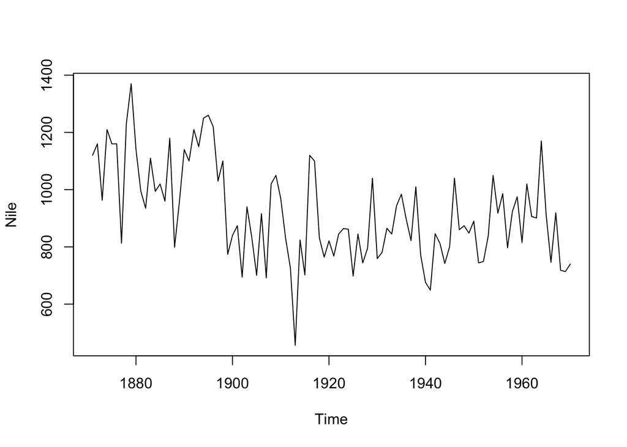

```r
plot(Nile)
```

```r
Box.test(Nile, lag = 10, type = "Ljung-Box")
```

```
##
##  Box-Ljung test
##
## data:  Nile
## X-squared = 88.127, df = 10, p-value = 1.255e-14
```

```r
Box.test(Nile, lag =10, type = "Box-Pierce")
```

```
##
##  Box-Pierce test
##
## data:  Nile
## X-squared = 83.229, df = 10, p-value = 1.166e-13
```

According to these results, we can find that the p-values are both smaller than the critical value 0.05. Therefore, we can reject the null hypothesis that the measurements of the river Nile is random.

### Test 30 BDS test

Question the test adrreses:

**Is a time series independent and identically distributed?**

To use this test:

- detect complex and non-linear patterns
- single time series

We will continue to use the `Nile` dataset and check if there is any non-random or non-linear patterns.

```r
bds.test(Nile)
```

```
##
##   BDS Test
##
## data:  Nile
##
## Embedding dimension =  2 3
##
## Epsilon for close points =   84.6138 169.2275 253.8413 338.4550
##
## Standard Normal =
##       [ 84.6138 ] [ 169.2275 ] [ 253.8413 ] [ 338.455 ]
## [ 2 ]      2.9223       6.9347       6.7724      5.6218
## [ 3 ]      1.9868       7.4144       7.6433      6.5196
##
## p-value =
##       [ 84.6138 ] [ 169.2275 ] [ 253.8413 ] [ 338.455 ]
## [ 2 ]      0.0035            0            0           0
## [ 3 ]      0.0469            0            0           0
```

According to the result, we can find that all p-values are smaller than the critical value 0.05. Therefore, we can reject the null hypothesis that the Nile dataset is independent and identically distributed. It suggests the patterns in the Nile dataset are more complex and maybe non-linear.

### Test 31 Wald-Wolfowitz Two-Sample Run test

Question the test adrreses:

**Do two independent samples come from populations having the same distribution?**

To use this test:

- combining two samples together
- ranking with the run test

We will use the Nile dataset to see whether the first 50 years are different from the last 50 years.

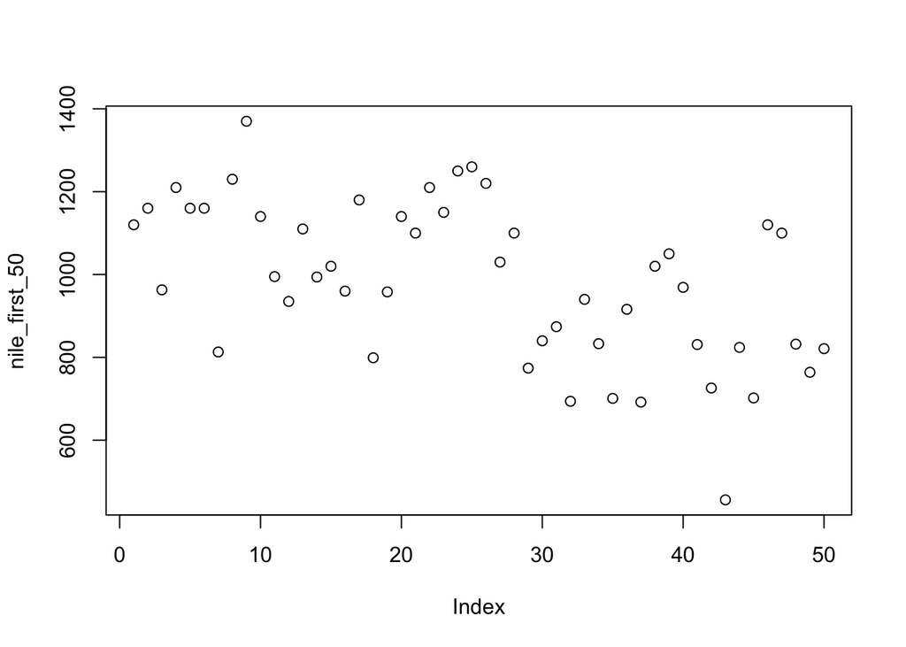

```r
nile_first_50 <- Nile[1:50]
nile_last_50 <- Nile[51:100]
plot(nile_first_50)
```

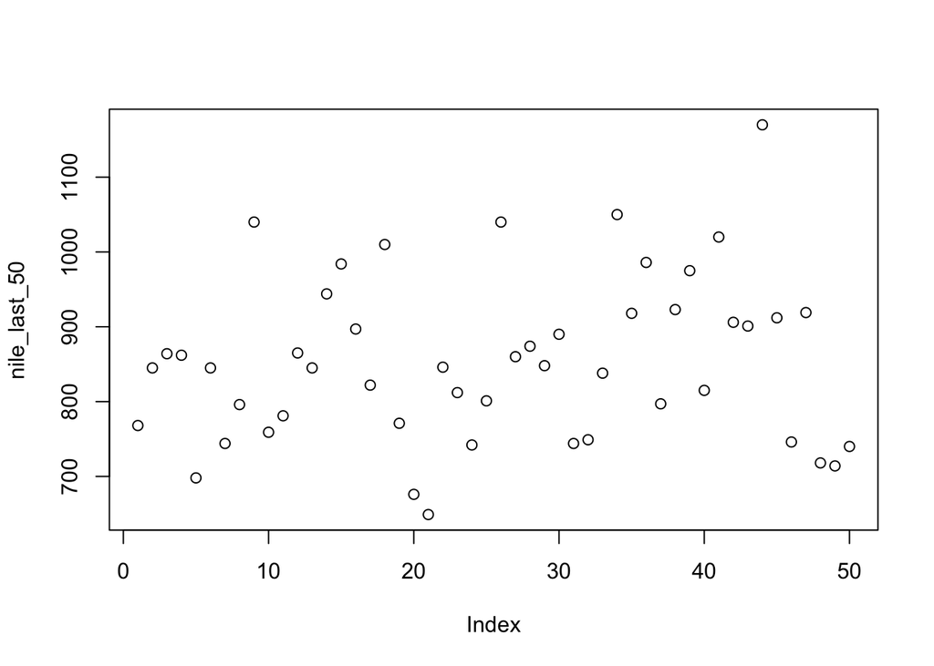

```r
plot(nile_last_50)
```

```r
combined_nile <- c(nile_first_50,nile_last_50)
group_labels <- factor(c(rep("first", 50), rep("last", 50)))

sorted_groups <- group_labels[order(combined_nile)]
tseries::runs.test(sorted_groups)
```

```
##
##  Runs Test
##
## data:  sorted_groups
## Standard Normal = -2.0102, p-value = 0.04441
## alternative hypothesis: two.sided
```

According to the result, we can find that the p-value is smaller than the critical value 0.05. Therefore, we can reject the null hypothesis that there is no difference between the first 50 years and last 50 years. The test suggests that the two samples are not randomly mixed, which means the distribution of the Nile’s flow in the first 50 years is likely different from its distribution in the last 50 years.

## Variances and Dispersion

### Test 32 Mood’s Test

Question the test adrreses:

**Do two independent samples come from the same distribution?**

To use this test:

- two samples are assumed to have same medians and shape

We will compare the spread of weights for chicks fed **“casein”** versus those fed **“sunflower”**. Visually, their average weights look similar, but is the consistency of the weight gain the same?

we can use the `mood.test()` function.

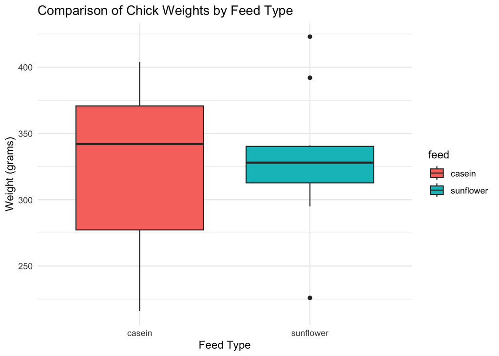

```r
casein_v_sunflower <- chickwts %>%
  filter(feed %in% c("casein", "sunflower"))

ggplot(casein_v_sunflower, aes(x = feed, y = weight, fill = feed)) +
  geom_boxplot() +
  labs(title = "Comparison of Chick Weights by Feed Type",
       x = "Feed Type",
       y = "Weight (grams)") +
  theme_minimal()
```

```r
mood.test(weight ~ feed, data = casein_v_sunflower)
```

```
##
##  Mood two-sample test of scale
##
## data:  weight by feed
## Z = 1.3501, p-value = 0.177
## alternative hypothesis: two.sided
```

According to the result, we can find that the p-value is larger than the critical value 0.05. Therefore, we can not reject the null hypothesis that these two independent samples come from the same distribution.

### Test 33 F-test of Equality of Variances

Question the test adrreses:

**Are the variances of two samples equal?**

To use this test:

- highly sensitive to the data being normally distributed
- parametric test, very powerful

We will use the F-test on the same two groups: “casein” vs. “sunflower”. This will let us compare the result from a parametric test (F-test) to the nonparametric one (Mood’s test). The function for F-test is `var.test()`.

```r
casein_v_sunflower <- chickwts %>%
  filter(feed %in% c("casein", "sunflower"))

var.test(weight ~ feed, data = casein_v_sunflower)
```

```
##
##  F test to compare two variances
##
## data:  weight by feed
## F = 1.7408, num df = 11, denom df = 11, p-value = 0.3718
## alternative hypothesis: true ratio of variances is not equal to 1
## 95 percent confidence interval:
##  0.5011282 6.0469059
## sample estimates:
## ratio of variances
##           1.740769
```

According to the result, we can find that the p-value is larger than the critical value. Therefore, we can not reject the null hypothesis that the variances of casein group and sunflower group are equal.

### Test 34 Pitman-Morgan Test

Question the test adrreses:

**Are the variances of two correlated sample equal?**

To use this test:

- paired data
- testing the correlation between sum and variances
- highly sensitive to the data being normally distributed

We will use `sleep` dataset again, as it contains paired data (each of the 10 subjects was tested on two different drugs). We can test if the variance in “extra sleep” was different for Drug 1 compared to Drug 2.

The function for this is `pitman.morgan.test.default()` from the `PairedData` package.

```r
if (!require("PairedData")) {
  install.packages("PairedData")
  library(PairedData)
}
pitman.morgan.test.default(drug1_sleep, drug2_sleep)
```

```
##
##  Paired Pitman-Morgan test
##
## data:  drug1_sleep and drug2_sleep
## t = -0.52636, df = 8, p-value = 0.6129
## alternative hypothesis: true ratio of variances is not equal to 1
## 95 percent confidence interval:
##  0.3080221 2.0691727
## sample estimates:
## variance of x variance of y
##      3.200556      4.009000
```

According to the result, we can find that the p-value is larger than the critical value 0.05. Therefore, we can not reject the null hypothesis that the variances from drug 1 and drug 2 are equal.

## Test 35-40 The Homogeneity of Variance Family

All these series of tests aim to answer the same question:

**Do multiple independent samples come from populations with equal variances?**

### Test 35 Ansari-Bradley Test

To use this test:

- data are assumed to be continuous
- data are measured at ordinary scale

```r
casein_v_sunflower <- chickwts %>%
  filter(feed %in% c("casein", "sunflower"))

ansari.test(weight ~ feed, data = casein_v_sunflower)
```

```
##
##  Ansari-Bradley test
##
## data:  weight by feed
## AB = 64.5, p-value = 0.1177
## alternative hypothesis: true ratio of scales is not equal to 1
```

According to the result, we can find that p-value is larger than the critical value 0.05. Therefore, we can not reject the null hypothesis that these two samples have the same variances.

### Test 36 Bartlett Test

To use this test:

- sensitive to data being normal distribution

We will use `chickwts` dataset to compare variances from all feeds.

```r
bartlett.test(weight ~ feed, data = chickwts)
```

```
##
##  Bartlett test of homogeneity of variances
##
## data:  weight by feed
## Bartlett's K-squared = 3.2597, df = 5, p-value = 0.66
```

According to the results, we can find that the p-value is larger than the critical value. Therefore, we can not reject the null hypothesis that variances from all feed are the same.

### Test 37 Fligner-Killeen Test

- nonparametric test
- more robust
- data can be assumed not to be normally distributed

We will compare the results from Fligner-Kileen test and Bartlett test to see anything different.

```r
fligner.test(weight ~ feed, data = chickwts)
```

```
##
##  Fligner-Killeen test of homogeneity of variances
##
## data:  weight by feed
## Fligner-Killeen:med chi-squared = 3.8109, df = 5, p-value = 0.577
```

According to the results, we get the exact same conclusion with Bartlett test.

### Test 38 Levene’s Test of Equality of Variance

To use this test:

- data are assumed not to be normally distributed

The function `leveneTest()` is in the `car` package, which we’ve used before. Let’s run it on our `chickwts` data to see if our conclusion holds a third time.

```r
if (!require("car")) {
  install.packages("car")
  library(car)
}

leveneTest(weight ~ feed, data = chickwts)
```

|  | Df | F value | Pr(>F) |
| --- | --- | --- | --- |
| group | 5 | 0.7492639 | 0.5896095 |
|  | 65 | NA | NA |

According to the results, we get the same result again.

### Test 39 Cochran’s C Test

Question the test adrreses:

**Is single largest variance among a group of samples an outlier?**

To use this test:

- equal sample size across all groups
- measure the largest variances as the outliers

We’ll use the `InsectSprays` data and the `cochran.test` function from the `outliers` package.

```r
if (!require("outliers")) {
  install.packages("outliers")
  library(outliers)
}

summary(InsectSprays)
```

```
##      count       spray
##  Min.   : 0.00   A:12
##  1st Qu.: 3.00   B:12
##  Median : 7.00   C:12
##  Mean   : 9.50   D:12
##  3rd Qu.:14.25   E:12
##  Max.   :26.00   F:12
```

```r
cochran.test(count ~ spray, data = InsectSprays)
```

```
##
##  Cochran test for outlying variance
##
## data:  count ~ spray
## C = 0.41832, df = 12, k = 6, p-value = 0.004435
## alternative hypothesis: Group F has outlying variance
## sample estimates:
##         A         B         C         D         E         F
## 22.272727 18.242424  3.901515  6.265152  3.000000 38.606061
```

According to the results, we can find that the p-value is smaller than the critical value. Therefore, we can reject the null hypothesis that there are no variances as outliers from all groups. The variance of **spray F** is significantly larger than the variances of the other sprays.

### Test 40 Brown-Forsythe Test

- use medians for test
- more robust and general-purpose

We will run this test on `InsectSprays` data to see what it says about the overall equality of variances. The function is `levene.test()` from the `lawstat` package, and we specify `location = "median"` to make it a Brown-Forsythe test.

```r
levene.test(InsectSprays$count, InsectSprays$spray, location = "median")
```

```
##
##  Modified robust Brown-Forsythe Levene-type test based on the absolute
##  deviations from the median
##
## data:  InsectSprays$count
## Test Statistic = 3.8214, p-value = 0.004223
```

According to the result, we can find that the p-value is smaller than the critical value. We can reject the null hypothesis that the variances across all groups are the same.

### Test 41 Mauchly’s Sphericity Test

Question the test adrreses:

**Are the variances of the differences between all possible pairs of groups in a repeated measures analysis of variance equal?**

To use this test:

- variances of the differences of comparison groups need to be equal
- repeated measures for ANOVA analysis

We will use `ChickWeight` and `sleep` to continue practice this test.

```r
sleep_wide <- reshape(sleep, idvar = "ID", timevar = "group", direction = "wide", sep = "_")
sleep_matrix <- as.matrix(sleep_wide[,c('extra_1', 'extra_2')])

lm_sleep <- lm(sleep_matrix ~ 1)
mauchly.test(lm_sleep, X = ~1)
```

```
##
##  Mauchly's test of sphericity
##  Contrasts orthogonal to
##  ~1
##
##
## data:  SSD matrix from lm(formula = sleep_matrix ~ 1)
## W = 1, p-value = 1
```

```r
chick_subset <- ChickWeight[ChickWeight$Time %in% c(0,2,4,6),]
chick_subset <- chick_subset[chick_subset$Chick %in% 1:10,]

chick_wide <- reshape(chick_subset, idvar = "Chick", timevar = "Time", direction = "wide", sep = "_")
chick_matrix <- as.matrix(chick_wide[,c("weight_0", "weight_2", "weight_4", "weight_6")])
chick_matrix <- na.omit(chick_matrix)

lm_chick <- lm(chick_matrix ~ 1)
mauchly.test(lm_chick, X= ~1)
```

```
##
##  Mauchly's test of sphericity
##  Contrasts orthogonal to
##  ~1
##
##
## data:  SSD matrix from lm(formula = chick_matrix ~ 1)
## W = 0.53701, p-value = 0.4439
```

According to the results, we can find that the p-value in practice 1 is 1 and the p-value in practice 2 is 0.4439. Both of them are larger than the critical value 0.05. For the practice 1, there are only two conditions in the test so there is no variances to compare. For the practice 2, we can not reject the null hypothesis that the variances of comparison groups are equal.

### Test 42 Binomial Test

Question the test adrreses:

**Do the proportion on of individuals falling in each category diﬀer from chance? Or does the proportion on of individuals falling into each category differ from some pre-specified probabilities of falling into those categories?**

A simple way to understand this test is that if we flip a coin 30 times and get 25 heads, this test can tell us the exact probability of that happening with a fair coin.

```r
binom.test(x = 25, n = 30, p = 0.5)
```

```
##
##  Exact binomial test
##
## data:  25 and 30
## number of successes = 25, number of trials = 30, p-value = 0.0003249
## alternative hypothesis: true probability of success is not equal to 0.5
## 95 percent confidence interval:
##  0.6527883 0.9435783
## sample estimates:
## probability of success
##              0.8333333
```

### Test 43 One-Sample Proportions Test

Question the test adrreses:

**Is the observed proportion from a random experiment equal to some pre-specified probability?**

This test is similar with Binomial test. It is suitable for large sample size. We have 100 people in a survey and 52 of them believe they prefer option A. We can test whether this is significantly from a 50% of market share.

```r
prop.test(x = 52, n = 100, p =0.5)
```

```
##
##  1-sample proportions test with continuity correction
##
## data:  52 out of 100, null probability 0.5
## X-squared = 0.09, df = 1, p-value = 0.7642
## alternative hypothesis: true p is not equal to 0.5
## 95 percent confidence interval:
##  0.4183183 0.6201278
## sample estimates:
##    p
## 0.52
```

According to this result, we can find that the p-value is larger than the critical value 0.05. Therefore, we can not reject the null hypothesis that our survey result shows the same proportion of market share.

### Test 44 One-Sample Poisson Test

Question the test adrreses:

**Is the rate parameter of a Poisson distributed sample significantly different from a hypothesized value?**

To use this test:

- count data

Researchers observed **6 cases** of a particular cancer in a group of relatives, but based on the general population, they only **expected 6.2 cases**. Is the observed number significantly different from the expected number?

```r
poisson.test(x = 6, T = 6.2)
```

```
##
##  Exact Poisson test
##
## data:  6 time base: 6.2
## number of events = 6, time base = 6.2, p-value = 1
## alternative hypothesis: true event rate is not equal to 1
## 95 percent confidence interval:
##  0.3551442 2.1063668
## sample estimates:
## event rate
##  0.9677419
```

According to the result, we can find that the p-value is larger than the critical value. Therefore, we can not reject the null hypothesis that the observed number is significant different from the expected number.

### Test 45 Pairwise Comparison of Proportions Test

Question the test adrreses:

**Is the difference between the pairwise proportions in three or more samples significant?**

To use this test:

- three or more than three groups

Suppose we have data from six different hospital wards on the proportion of patients who recovered after a treatment.

| Ward | Recovered | Not Recovered |
| --- | --- | --- |
| s1 | 95 | 106 |
| s2 | 181 | 137 |
| s3 | 76 | 85 |
| s4 | 13 | 29 |
| s5 | 11 | 26 |
| s6 | 201 | 179 |

```r
recovery_data <- matrix(c(95, 106, 181, 137, 76, 85, 13, 29, 11, 26, 201, 179),
                      ncol = 2, byrow = TRUE)


colnames(recovery_data) <- c("Recovered", "Not Recovered")
rownames(recovery_data) <- c("s1", "s2", "s3", "s4", "s5", "s6")

pairwise.prop.test(recovery_data)
```

```
##
##  Pairwise comparisons using Pairwise comparison of proportions
##
## data:  recovery_data
##
##    s1    s2    s3    s4    s5
## s2 0.437 -     -     -     -
## s3 1.000 0.553 -     -     -
## s4 0.658 0.039 0.658 -     -
## s5 0.658 0.042 0.658 1.000 -
## s6 1.000 1.000 1.000 0.146 0.146
##
## P value adjustment method: holm
```

According to the result, we can find that the p-values between s2 and s4, s2 and s5 are smaller than the critical value. Therefore, we can only reject the null hypothesis between these two groups that s2 and s4, s2 and s5 are significantly different.

### Test 46 Two-Sample Poisson Test

Question the test adrreses:

**Is the rate parameter of a Poisson distributed sample significantly different from another?**

This is the two-sample version of the Poisson test.

To use this test:

- two independent samples
- compare the rate of events

We will test two samples:

- **Sample 1:** Observed 10 events over a “time base” or exposure of 20,000 units.
- **Sample 2:** Observed 2 events over a “time base” or exposure of 17,877 units.

```r
poisson.test(c(10,2),c(20000,17877))
```

```
##
##  Comparison of Poisson rates
##
## data:  c(10, 2) time base: c(20000, 17877)
## count1 = 10, expected count1 = 6.3363, p-value = 0.04213
## alternative hypothesis: true rate ratio is not equal to 1
## 95 percent confidence interval:
##   0.9524221 41.9509150
## sample estimates:
## rate ratio
##    4.46925
```

According to the result, we can find that the p-value is smaller than the critical value. Therefore, we can reject the null hypothesis that the rate of parameters of these two samples are significantly different.

### Test 47 Multiple Sample Proportions Test

Question the test adrreses:

**Is the difference between the observed proportions from two or more samples significantly different from zero?**

To use this test:

- two or more independent groups
- compare the proportions of successes

We will use two groups to practice this test:

- **Group 1 (Male Faculty):** 18 out of 30 were trained at top-tier schools (18 successes, 30 trials).
- **Group 2 (Female Faculty):** 17 out of 24 were trained at top-tier schools (17 successes, 24 trials).

```r
prop.test(c(18,17),c(30,24))
```

```
##
##  2-sample test for equality of proportions with continuity correction
##
## data:  c(18, 17) out of c(30, 24)
## X-squared = 0.29335, df = 1, p-value = 0.5881
## alternative hypothesis: two.sided
## 95 percent confidence interval:
##  -0.3984195  0.1817529
## sample estimates:
##    prop 1    prop 2
## 0.6000000 0.7083333
```

According to the result, we can find that the p-value is larger than the critical value. Therefore, we can not reject the null hypothesis that there is differences between the rate of successes in the two groups.

### Test 48 Chi-Squared Test for Linear Trend

Question the test adrreses:

**Is there a linear trend in the proportions across multiple ordered categories?**

To use this test:

- three or more ordered groups
- find a linear trend in the proportions of success

We have three groups with increasing dosage levels.

- **Group 1 (10mg):** 10 successes out of 50 trials.
- **Group 2 (20mg):** 17 successes out of 50 trials.
- **Group 3 (30mg):** 25 successes out of 50 trials.

```r
success <- c(10, 17, 25)

totals <- c(50, 50, 50)

prop.trend.test(success, totals)
```

```
##
##  Chi-squared Test for Trend in Proportions
##
## data:  success out of totals ,
##  using scores: 1 2 3
## X-squared = 9.9343, df = 1, p-value = 0.001622
```

According to the result, we can find that the p-value is smaller than the critical value. Therefore, we can reject the null hypothesis that there is no linear trend.

### Test 49 Pearson’s Paired Chi-Squared Test

Question the test adrreses:

**Are the paired observations on two variables in a contingency table independent of each other?**

To use this test:

- two categorical variables

We have a contingency table showing the voting patterns of 100 citizens, categorized by gender and political party.

| Gender | Labour | Conservative |
| --- | --- | --- |
| Male | 20 | 30 |
| Female | 30 | 20 |

We want to test if a person’s gender is independent of their choice of political party.

```r
voting_data <- as.table(rbind(c(20, 30), c(30, 20)))

dimnames(voting_data) <- list(gender = c("Male", "Female"), party = c("Labour", "Conservative"))
chisq.test(voting_data, correct = FALSE)
```

```
##
##  Pearson's Chi-squared test
##
## data:  voting_data
## X-squared = 4, df = 1, p-value = 0.0455
```

According to the result, we can find that p-value is smaller than the critical value. Therefore, we can reject the null hypothesis that the person’s gender is independent of their choice of party.

### Test 50 Fisher’s Exact Test

Question the test adrreses:

**Are the paired observations on two variables in a contingency table independent of each other?**

To use this test:

- small sample size
- two categorical variables

| Gender | Labour | Conservative |
| --- | --- | --- |
| Male | 2 | 3 |
| Female | 3 | 2 |

We want to test if a person’s gender is independent of their choice of political party.

```r
voting_data <- as.table(rbind(c(2, 3), c(3, 2)))

dimnames(voting_data) <- list(gender = c("Male", "Female"), party = c("Labour", "Conservative"))
fisher.test(voting_data)
```

```
##
##  Fisher's Exact Test for Count Data
##
## data:  voting_data
## p-value = 1
## alternative hypothesis: true odds ratio is not equal to 1
## 95 percent confidence interval:
##  0.01931867 9.42971111
## sample estimates:
## odds ratio
##  0.4831013
```

According to the result, we can find that the p-value is larger than the critical value. Therefore, we can not reject the null hypothesis. There is no significantly association between a person’s gender and their choice of political party.

### Test 51 Cochran-Mantel-Haenszel Test

Question the test adrreses:

**Is there a relationship between two categorical variables after adjusting for control variables?**

To use this test:

- More advanced chi-squared test
- test relationships between two categorical variables and control for a third categorical variable

We will create a treatment example from the book. We want to see if a treatment (“Drug” vs. “Placebo”) is associated with a response (“Improved” vs. “No Change”), while controlling for sex (“Male” vs. “Female”).

```r
treatment_data <- array(
  c(12,16,7,19,
    16,11,5,20),
  dim = c(2,2,2),
  dimnames = list(
    Treatment = c("Drug","Placebo"),
    Response = c("Improved","No Change"),
    Sex = c("Male","Female")
  )
)
ftable(treatment_data)
```

```
##                     Sex Male Female
## Treatment Response
## Drug      Improved        12     16
##           No Change        7      5
## Placebo   Improved        16     11
##           No Change       19     20
```

```r
mantelhaen.test(treatment_data)
```

```
##
##  Mantel-Haenszel chi-squared test with continuity correction
##
## data:  treatment_data
## Mantel-Haenszel X-squared = 7.1983, df = 1, p-value = 0.007297
## alternative hypothesis: true common odds ratio is not equal to 1
## 95 percent confidence interval:
##  1.445613 7.593375
## sample estimates:
## common odds ratio
##          3.313168
```

According to the result, we can find that the p-value is smaller than the critical value 0.05. Therefore, we can reject the null hypothesis that there is no relationship between the treatment and response even after controlling for sex.

### Test 52 McNemar’s Test

Question the test adrreses:

**Is there a difference between paired proportions?**

To use this test:

- paired or matched categorical data
- same subject twice and the outcome is binary (yes/no)
- suitable for “before and after” test

From the book, we create a table for the diagnostic tests. We are comparing two diagnostic tests for tuberculosis (sputum culture & chest radiography) on the same group of patients.

```r
diagnostic_data <- matrix(
  c(59,4,128,20),
  nrow = 2,
  dimnames = list(
    "Radiography" = c("Positive","Negative"),
    "Sputum" = c("Positive", "Negative"))
)
ftable(diagnostic_data)
```

```
##             Sputum Positive Negative
## Radiography
## Positive                 59      128
## Negative                  4       20
```

```r
mcnemar.test(diagnostic_data)
```

```
##
##  McNemar's Chi-squared test with continuity correction
##
## data:  diagnostic_data
## McNemar's chi-squared = 114.61, df = 1, p-value < 2.2e-16
```

According to the result, we can find that the p-value is smaller than the critical value. Therefore, we can reject the null hypothesis that two tests have the same proportion of positive results.

### Test 53 Equal Means in a One-way Layout (ANOVA)

Question the test adrreses:

**Do three or more samples come from populations with the same mean?**

To use this test:

- extension of the independent two-sample t-test Test 15 Two-sample t-test for the Difference in Sample Means
- three or more groups of samples
- assume data to be normally distributed
- assume variances across different groups to be equal

We will comeback to the `chickwts` dataset (Let’s say “thank you chicks!”) and compare the effects of six different feeds.

```r
oneway.test(weight ~ feed, data= chickwts, var.equal = TRUE)
```

```
##
##  One-way analysis of means
##
## data:  weight and feed
## F = 15.365, num df = 5, denom df = 65, p-value = 5.936e-10
```

According to the result, we can find that the p-value is smaller than the critical value. Therefore, we can reject the null hypothesis that there is no significant difference in the mean weight of chicks across six different groups.

The ANOVA test tells us that at least one group is different from others, but it doesn’t tell us which specific groups are different. To find that out, we would need to perform a follow-up test, like the Test 17 Pairwise t-test with Common Variance.

### Test 54 Welch-test for more than two samples (Welch’s ANOVA)

Question the test adrreses:

**Do your three or more samples come from populations with the same mean?**

To use this test:

- do not assume equal variances across all groups
- more robust alternative to the standard ANOVA test

Therefore, we only need to set the `var.euqal = FALSE`.

```r
oneway.test(weight ~ feed, data= chickwts, var.equal = FALSE)
```

```
##
##  One-way analysis of means (not assuming equal variances)
##
## data:  weight and feed
## F = 19.662, num df = 5.000, denom df = 29.952, p-value = 1.177e-08
```

According to the result, we can find that the p-value is smaller than the critical value. Therefore, we can reject the null hypothesis. Comparing with the result from test 53, we can find that the Welch’s ANOVA test has higher F value and larger p value than the standard ANOVA test as it is more robust with fewer constraints.

### Test 55 Kruskal-Wallis Rank Sum Test

Question the test adrreses:

**Do your three or more samples come from populations with the same mean?**

To use this test:

- nonparametric equivalent of the one-way ANOVA
- central tendency of three or more independent groups
- do not assume the normality assumption of ANOVA
- the extension of the Test 24 Wilcoxon Rank Sum Test for the Difference in Medians

```r
kruskal.test(weight ~ feed, data = chickwts)
```

```
##
##  Kruskal-Wallis rank sum test
##
## data:  weight by feed
## Kruskal-Wallis chi-squared = 37.343, df = 5, p-value = 5.113e-07
```

According to the result, we can find that p-value is smaller than the critical value. Therefore, we can reject the null hypothesis.

Kruskal-Wallis Rank Sum test has even fewer constraints. Therefore, the p-value is larger than the Welch’s ANOA.

### Test 56 Friedman’s Test

Question the test adrreses:

**Are the distributions from various groups the same across repeated measures?**

To use this test:

- repeated measures of ANOVA
- three or more related/paired groups of samples
- assume data not to be normally distributed
- extension of Test 20 Matched Pairs Wilcoxon Test

Friedman Test in R requires matrix data. Therefore, we will create the sample data based on the book.

```r
diet_data <- matrix(c(
  8, 8, 7,  7, 6, 6,  6, 8, 6,  8, 9, 7,
  5, 8, 5,  9, 7, 7,  7, 7, 7,  8, 7, 7,
  8, 6, 8,  7, 6, 6,  7, 8, 6,  9, 9, 6
), nrow = 12, byrow = TRUE,
dimnames = list(
  Subject = 1:12,
  Diet = c("Healthy Balanced","Low Fat","Low Carb")
))

ftable(diet_data)
```

```
##         Diet Healthy Balanced Low Fat Low Carb
## Subject
## 1                           8       8        7
## 2                           7       6        6
## 3                           6       8        6
## 4                           8       9        7
## 5                           5       8        5
## 6                           9       7        7
## 7                           7       7        7
## 8                           8       7        7
## 9                           8       6        8
## 10                          7       6        6
## 11                          7       8        6
## 12                          9       9        6
```

```r
friedman.test(diet_data)
```

```
##
##  Friedman rank sum test
##
## data:  diet_data
## Friedman chi-squared = 7.6, df = 2, p-value = 0.02237
```

According to the result, we can find that the p-value is smaller than the critical value. Therefore, we can reject the null hypothesis that there is no difference in the perceived energy levels across the three diets.

### Test 57 Quade Test

Question the test adrreses:

**Are the distributions from various groups the same across repeated measures?**

To use this test:

- related (paired) samples
- more powerful than the Friedman test
- small number of groups

```r
quade.test(diet_data)
```

```
##
##  Quade test
##
## data:  diet_data
## Quade F = 3.9057, num df = 2, denom df = 22, p-value = 0.03535
```

According to the result, we can find that the p-value is smaller than the critical value. Therefore, we can reject the null hypothesis that there is no difference in the perceived energy levels across the three diets.

## Testing for Normality

### Test 58 D’Agostino Test of Skewness

Question the test adrreses:

**Is the data skewed (symmetric or long tail on one side)?**

To use this test:

- for normality assumption
- looking for Skewness (symmetric, long tail)

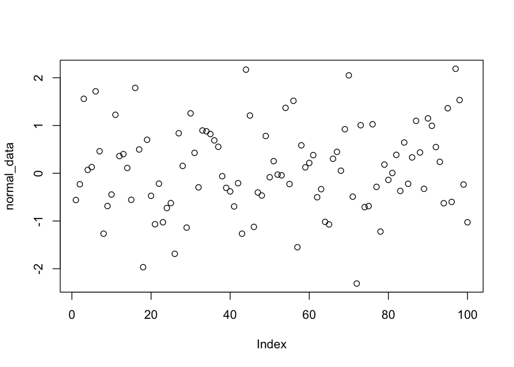

```r
if (!require("moments")) {
  install.packages("moments")
  library(moments)
}

set.seed(123)
normal_data <- rnorm(100)
plot(normal_data)
```

```r
agostino.test(normal_data)
```

```
##
##  D'Agostino skewness test
##
## data:  normal_data
## skew = 0.060499, z = 0.262698, p-value = 0.7928
## alternative hypothesis: data have a skewness
```

According to the result, we can find that the p-value is larger than the critical value. Therefore, we can not reject the null hypothesis that the data is not skewed.

### Test 59 Anscombe-Glynn Test of Kurtosis

Question the test adrreses:

**Does the sample exhibit more (or less) kurtosis relative to the normal distribution?**

**Kurtosis:** Does the data have “heavy” or “light” tails compared to a normal distribution?

A distribution with high kurtosis has a sharper peak and heavier tails (meaning more outliers are likely), while a distribution with low kurtosis is flatter with lighter tails.

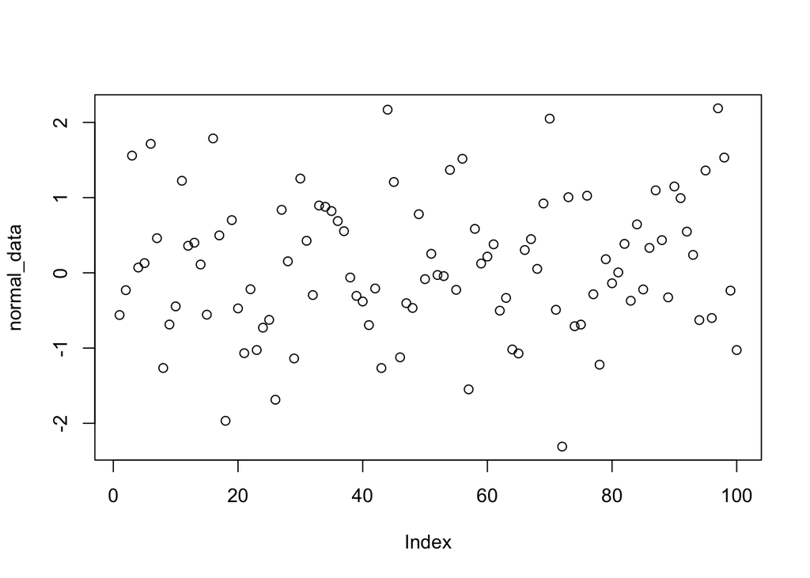

```r
if (!require("moments")) {
  install.packages("moments")
  library(moments)
}

set.seed(123)
normal_data <- rnorm(100)
plot(normal_data)
```

```r
anscombe.test(normal_data)
```

```
##
##  Anscombe-Glynn kurtosis test
##
## data:  normal_data
## kurt = 2.838947, z = -0.059837, p-value = 0.9523
## alternative hypothesis: kurtosis is not equal to 3
```

According to the result, the p-value is larger than the critical value. Therefore, we can not reject the null hypothesis that the data has the same kurtosis as a normal distribution.

### Test 60 Bonett-Seier Test of Kurtosis

Question the test adrreses:

**Does the sample exhibit more (or less) kurtosis relative to the normal distribution?**

To use this test:

- use Geary’s measure to measure kurtosis
- run multiple tests for the same property to improve confidence

Now we still use our previous normal_data here.

```r
bonett.test(normal_data)
```

```
##
##  Bonett-Seier test for Geary kurtosis
##
## data:  normal_data
## tau = 0.72928, z = -0.23812, p-value = 0.8118
## alternative hypothesis: kurtosis is not equal to sqrt(2/pi)
```

According to the result, the p-value is larger than the critical value. Therefore, we can not reject the null hypothesis that the data has the same kurtosis as a normal distribution.

Now let’s visualise these three tests for the normal distributions.

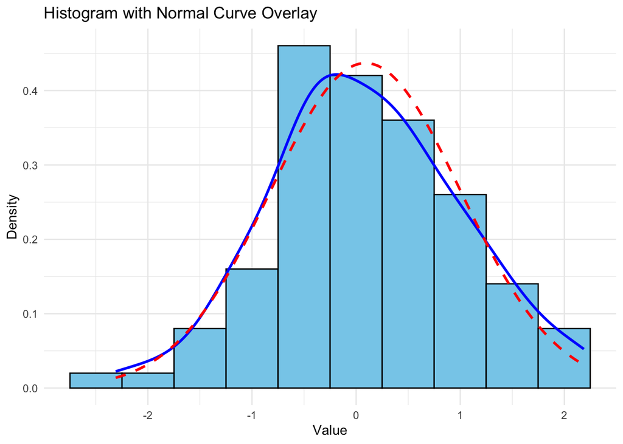

```r
df_normal_data <- data.frame(normal_data = normal_data)

ggplot(data = df_normal_data, aes(x = normal_data)) +
  geom_histogram(aes(y = ..density..), bins = 10, fill = "skyblue", color = "black") +
  geom_density(color = "blue", linewidth = 1) +
  stat_function(fun = dnorm, args = list(mean = mean(normal_data), sd = sd(normal_data)), color = "red", linewidth = 1, linetype = "dashed") +
  labs(title = "Histogram with Normal Curve Overlay",
       x = "Value", y = "Density") +
  theme_minimal()
```

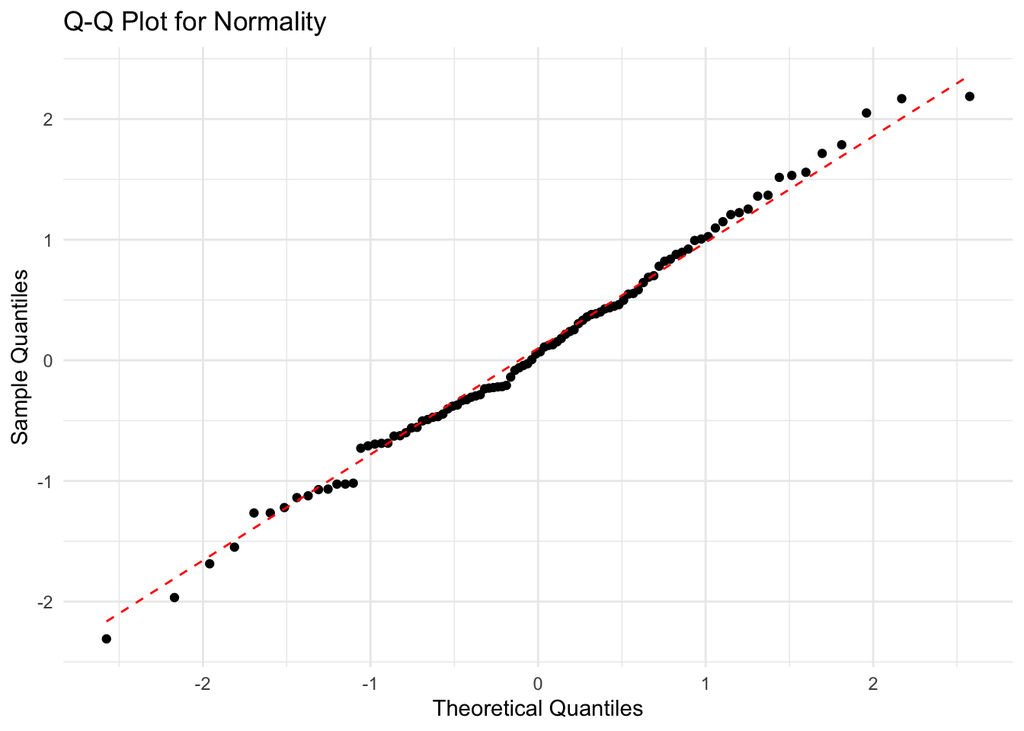

```r
ggplot(df_normal_data, aes(sample = normal_data)) +
  stat_qq() +
  stat_qq_line(color = "red", linetype = "dashed") +
  labs(title = "Q-Q Plot for Normality",
       x = "Theoretical Quantiles", y = "Sample Quantiles") +
  theme_minimal()
```

### Test 61 Shapiro-Wilk Test

Question the test adrreses:

**Is the sample from a normal distribution?**

To use this test:

- check for normality
- suitable for wide range of sample sizes

$H_0$:This data is normally distributed

We can use the built-in `iris` dataset to test whether the `Sepal.Length` for one of the species `setosa` is normally distibuted.

```r
setosa_sepal_length <- iris$Sepal.Length[iris$Species == "setosa"]

shapiro.test(setosa_sepal_length)
```

```
##
##  Shapiro-Wilk normality test
##
## data:  setosa_sepal_length
## W = 0.9777, p-value = 0.4595
```

According to the result, we can find that the p-value is larger than the critical value. Therefore, we can not reject the null hypothesis that the length of sepal of setosa is normally distributed.

### Test 62 Kolmogorov-Smirnov Test of Normality

Question the test adrreses:

**Is the sample from a normal distribution?**

To use this test:

- comparing the cumulative distribution function with the perfect distribution
- very general test to compare data to any theoretical distribution

$H_0$:This data is normally distributed

We will use this to compare with normal distribution “pnorm”.

```r
ks.test(setosa_sepal_length, "pnorm", mean=mean(setosa_sepal_length), sd=sd(setosa_sepal_length))
```

```
##
##  Asymptotic one-sample Kolmogorov-Smirnov test
##
## data:  setosa_sepal_length
## D = 0.11486, p-value = 0.5245
## alternative hypothesis: two-sided
```

According to the result, we can find that the p-value is larger than the critical value. Therefore, we can not reject the null hypothesis that the length of sepal of setosa is normally distributed.

Question the test adrreses:

**Is the sample from a normal distribution?**

To use this test:

- “goodness-of-fit” test for skewness (0) and kurtosis (3)

We will do this again on the `iris` dataset and we also need `tseries` package.

```r
if (!require("tseries")){
  install.packages("tseries")
  library(tseries)
}
jarque.bera.test(setosa_sepal_length)
```

```
##
##  Jarque Bera Test
##
## data:  setosa_sepal_length
## X-squared = 0.36208, df = 2, p-value = 0.8344
```

According to the result, we can find that the p-value is larger than the critical value. Therefore, we can not reject the null hypothesis that the data is normally distributed.

### Test 64-Test 68

- **Test 64 D’Agostino**: A combined test for both skewness and kurtosis. It’s very similar to the Jarque-Bera Test
- **Test 65 Anderson-Darling**: A modification of the K-S test which is more sensitive to deviations in the tails of the distribution
- **Test 66 Cramer-von Mises**: Another modification of the K-S test
- **Test 67 Lilliefors**: A specific correction of the K-S test when you have to estimate the mean and standard deviation from your sample
- **Test 68 Shapiro-Francis**: A simplified version of the Shapiro-Wilk test for large sample sizes.

```r
if (!require("nortest")){
  install.packages("nortest")
  library(nortest)
}

ad.test(setosa_sepal_length)
```

```
##
##  Anderson-Darling normality test
##
## data:  setosa_sepal_length
## A = 0.40799, p-value = 0.3352
```

```r
cvm.test(setosa_sepal_length)
```

```
##
##  Cramer-von Mises normality test
##
## data:  setosa_sepal_length
## W = 0.071753, p-value = 0.2597
```

```r
lillie.test(setosa_sepal_length)
```

```
##
##  Lilliefors (Kolmogorov-Smirnov) normality test
##
## data:  setosa_sepal_length
## D = 0.11486, p-value = 0.09693
```

```r
sf.test(setosa_sepal_length)
```

```
##
##  Shapiro-Francia normality test
##
## data:  setosa_sepal_length
## W = 0.9817, p-value = 0.5357
```

According to the results, all p-values are larger than the critical value. Therefore, we can not reject the null hypothesis that our data is normally distributed. However, Lilliefors test gives a interesting observation that our data might have a very slightly deviation from a perfect normal distribution that the other tests did not emphasise as much.

### Test 69 Maradia’s Test of Multivariate Nornality

Question the test adrreses:

**Is the sample of k factors drawn from the multivariate normal distribution?**

To use this test:

- check a whole set of variables together follows a multivariate normal distribution

We will test the four measurements of the seotsa species are multivariate normal. We will use `psych` package.

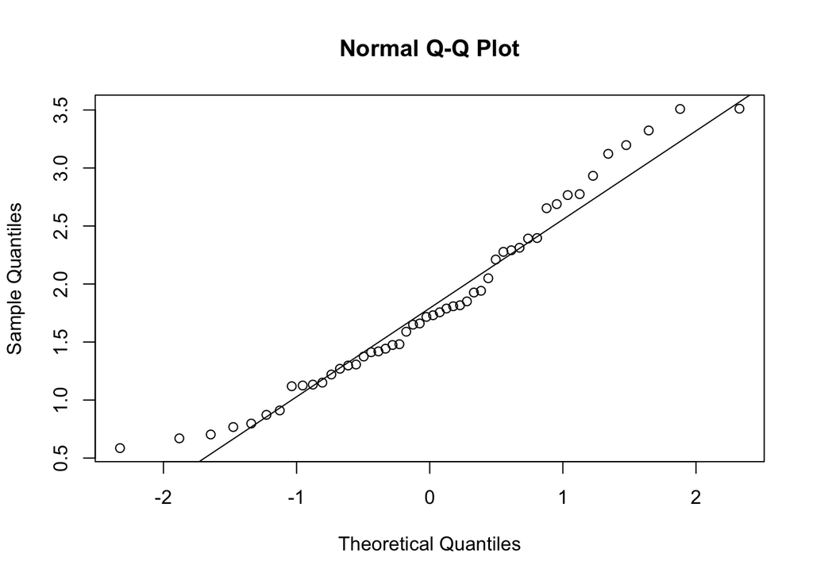

```
## Call: mardia(x = setosa_measurements)
##
## Mardia tests of multivariate skew and kurtosis
## Use describe(x) the to get univariate tests
## n.obs = 50   num.vars =  4
## b1p =  2.9   skew =  24.16  with probability  <=  0.24
##  small sample skew =  26.22  with probability <=  0.16
## b2p =  25.49   kurtosis =  0.76  with probability <=  0.45
```

```r
if (!require("psych")){
  install.packages("psych")
  library(psych)
}

setosa_measurements <- iris %>%
  filter(Species == "setosa") %>%
  dplyr::select(Sepal.Length, Sepal.Width, Petal.Length, Petal.Width)

mardia(setosa_measurements)
```

According to the result, we can find that all p-values are greater than the critical value. Therefore, we can not reject the null hypothesis that our measurements of setosa are multivariate normal.

## Goodness of Fit (Test 70-74)

### Test 70 -71 K-S Goodness of Fit & Anderson-Darling Goodness of Fit

These are the tests that we are familiar with in Test 62 Kolmogorov-Smirnov Test of Normality and Test 64-Test 68. In test 62, we will the “pnorm” to test normality. Here, we can use the rest of parameters to test different distributions.

| Distribution | R Code for CDF | Distribution | R Code for CDF |
| --- | --- | --- | --- |
| Beta | `"pbeta"` | Normal | `"pnorm"` |
| Binomial | `"pbinom"` | Poisson | `"ppois"` |
| Cauchy | `"pcauchy"` | Student’s t | `"pt"` |
| Chi-squared | `"pchisq"` | Uniform | `"punif"` |
| Exponential | `"pexp"` | Weibull | `"pweibull"` |
| F | `"pf"` | Wilcoxon | `"pwilcox"` |
| Gamma | `"pgamma"` | Logistic | `"plogis"` |
| Lognormal | `"plnorm"` |  |  |

### Test 72 Two sample K-S Test

Question the test adrreses:

**Do two independent random samples come from the same probability distribution?**

To use this test:

- two random samples

We can use the iris dataset to see whether the `sepal.length` of `setosa` and `petal.width` of `versicolor` are from the same distribution.

```r
setosa_sepal_length <- iris$Sepal.Length[iris$Species == "setosa"]

versicolor_petal_width <- iris$Petal.Width[iris$Species == "versicolor"]

ks.test(setosa_sepal_length, versicolor_petal_width, alternative = "two.sided")
```

```
##
##  Exact two-sample Kolmogorov-Smirnov test
##
## data:  setosa_sepal_length and versicolor_petal_width
## D = 1, p-value < 2.2e-16
## alternative hypothesis: two-sided
```

According to the result, we can find that the p-value is smaller than the critical value. Therefore, we can reject the null hypothesis that these two sample data are from the same distribution.

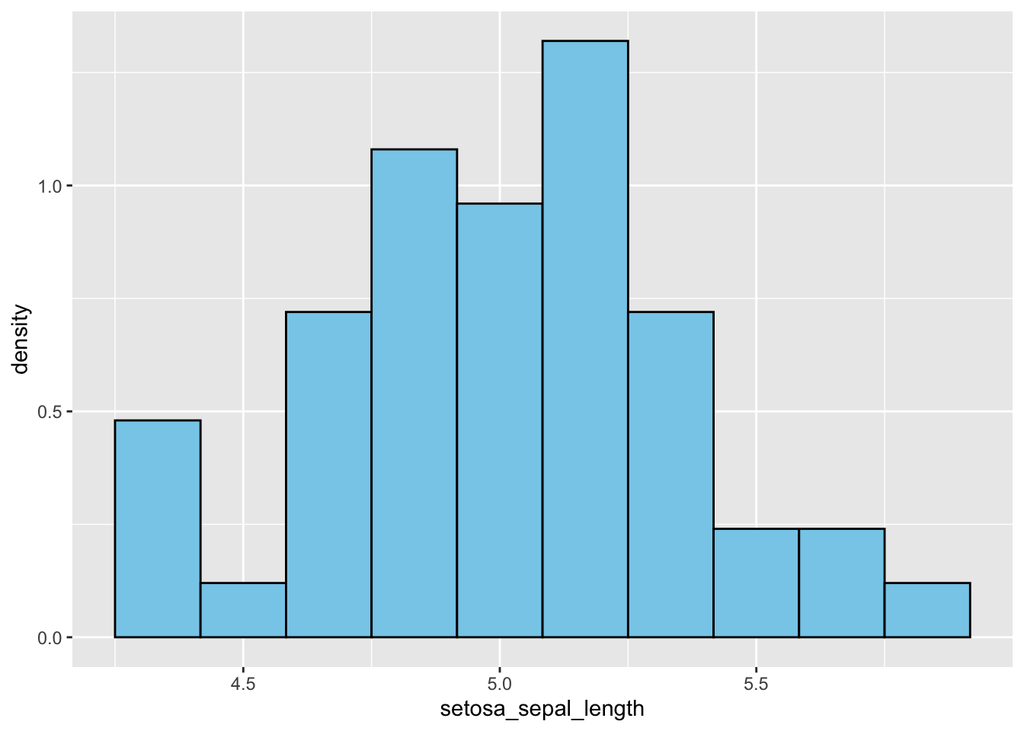

```r
test_72 <- tibble(setosa_sepal_length, versicolor_petal_width)

ggplot(data = test_72) +
  geom_histogram(aes(x = setosa_sepal_length, y =..density..), bins = 10, fill = "skyblue", color = "black" )
```

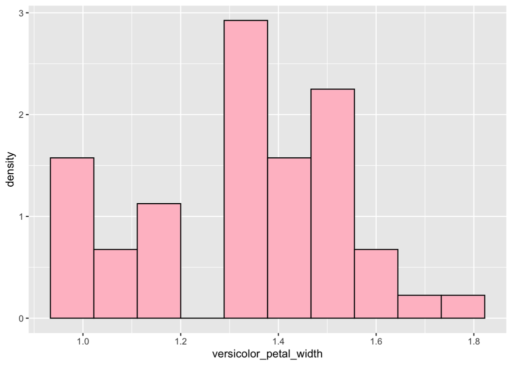

```r
ggplot(data = test_72) +
  geom_histogram(aes(x = versicolor_petal_width, y =..density..), bins =10, fill = "pink", color = "black")
```

### Test 73 Anderson-Darling Multiple Sample

This test extends the A-D test into multiple samples. It checks various samples from the same distribution. Similarly, we can continue from test 72 to test 73.

```r
if (!require("kSamples")){
  install.packages("kSamples")
  library(kSamples)
}

kSamples::ad.test(setosa_sepal_length, versicolor_petal_width)
```

```
##
##
##  Anderson-Darling k-sample test.
##
## Number of samples:  2
## Sample sizes:  50, 50
## Number of ties: 76
##
## Mean of  Anderson-Darling  Criterion: 1
## Standard deviation of  Anderson-Darling  Criterion: 0.74725
##
## T.AD = ( Anderson-Darling  Criterion - mean)/sigma
##
## Null Hypothesis: All samples come from a common population.
##
##                AD   T.AD  asympt. P-value
## version 1: 40.548 52.925       6.6576e-23
## version 2: 41.800 54.545       1.6267e-23
```

According to the result, we can find that the p-value is smaller than the critical value. Therefore, we can reject the null hypothesis that all samples come from a common population.

### Test 74 Brunner-Munzel Generalized Wilcoxon Test

Question the test adrreses:

**Are the scores on some ordinally scaled variable larger in one population than in another?**

To use this test:

- variances can not be assumed to be equal
- distribution is non-symmetric
- transformation of the data when small sample sizes

We will use the example from the book. We have two groups of football fans scoring the football game ending 0-0.

```r
fan1 <- c(2, 2, 4, 1, 1, 4, 1, 3, 1, 5, 2, 4, 1, 1)
fan2 <- c(3, 3, 4, 3, 1, 2, 3, 3, 1, 5, 4)

brunner.munzel.test(fan1, fan2, alternative = "two.sided", alpha = 0.05)
```

```
##
##  Brunner-Munzel Test
##
## data:  fan1 and fan2
## Brunner-Munzel Test Statistic = 1.1588, df = 22.72, p-value = 0.2586
## 95 percent confidence interval:
##  0.3953241 0.8709097
## sample estimates:
## P(X<Y)+.5*P(X=Y)
##        0.6331169
```

According to the result, the p-value is larger than the critical value. Therefore, we can not reject the null hypothesis.

## Detecting Outliers (Test 75-78)

### Test 75 Dixon’s Q Test

Question the test addresses:

**Do sample data contain an outlier?**

To use this test:

- usually small sample (<30)

We will use the example from the book. We will check the smallest value is an outlier.

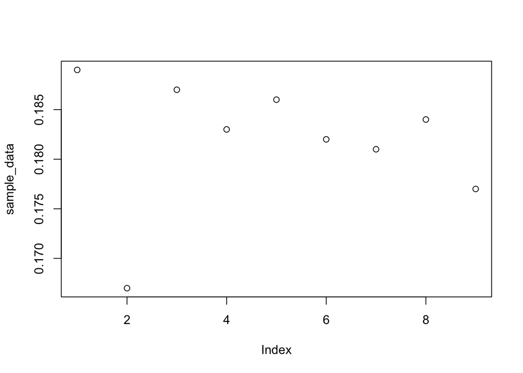

```r
if (!require("outliers")){
  install.packages("outliers")
  library(outliers)
}

sample_data <- c(0.189, 0.167, 0.187, 0.183, 0.186, 0.182, 0.181, 0.184, 0.177)

plot(sample_data)
```

```r
dixon.test(sample_data)
```

```
##
##  Dixon test for outliers
##
## data:  sample_data
## Q = 0.5, p-value = 0.1137
## alternative hypothesis: lowest value 0.167 is an outlier
```

According to the result, we can find that the p-value is larger than the critical value. Therefore, we can not reject the null hypothesis that the smallest value is not an outlier.

### Test 76 Chi-Squared Test for Outliers

Question the test addresses:

**Do my sample data contain an outlier?**

To use this test:

- the true population (which is rare)

We will use the example on the book.

```r
dependent.variable=c(3083,3140,3218,3239,3295,3374,3475,3569,3597,3725)
independent.variable=c(75,78,80,82,84,88,93,97,65,104)
```

```r
regression.model <- lm(dependent.variable ~ independent.variable)
residual <- rstudent(regression.model)
chisq.out.test(residual, variance = 1)
```

```
##
##  chi-squared test for outlier
##
## data:  residual
## X-squared.9 = 2176.1, p-value < 2.2e-16
## alternative hypothesis: highest value 51.6102457285332 is an outlier
```

According to the result, we can find that the p-value is smaller than the critical value. Therefore, we can reject the null hypothesis and find the highest value is an outlier.

### Test 77 Bonferroni Outlier Test

Question the test addresses:

**Do my sample data contain an outlier?**

To use this test:

- linear or multiple regression model

We will use the built-in cars dataset and test the linear model between distance and speed. We also need the `car` packages

```r
if (!require("car")){
  install.packages("car")
  library(car)
}
car_model <- lm(dist ~ speed, data = cars)
outlierTest(car_model)
```

```
## No Studentized residuals with Bonferroni p < 0.05
## Largest |rstudent|:
##    rstudent unadjusted p-value Bonferroni p
## 49 3.184993          0.0025707      0.12853
```

According to the result, we can find that the p-value is larger than the critical value. Therefore, we can not reject the null hypothesis that there is no outlier in the regression model.

### Test 78 Grubbs’ Test

To use this test:

- data are assumed to be normally distributed
- tested data are the minimum and maximum sample values

We can use the example from the book. Type can take from 10, 11, or 20. 10 is for one outlier and 11 is for two outliers on opposite tails, 20 is for two outliers in one tail.

```r
sample<-c(0.189,0.167,0.187,0.183,0.186,0.182,0.181,0.184,0.177)

grubbs.test(sample, type = 10, opposite = FALSE, two.sided = TRUE)
```

```
##
##  Grubbs test for one outlier
##
## data:  sample
## G = 2.24851, U = 0.28903, p-value = 0.03868
## alternative hypothesis: lowest value 0.167 is an outlier
```

According to the result, we can find that the p-value is smaller than the critical value. Therefore, we can reject the null hypothesis that there is no outlier in the sample data.

## Regression Diagnostics (Test 79-84)

### Test 79 Goldfeld-Quandt Test For heteroscedasticity

Question the test addresses:

**Are the residuals in a linear regression heteroscedastic?**

To use this test:

- linear or multiple regression model
- test estimated variance of the regression residuals are dependent on the values of the independent variables

We will continue to use our linear model between distance and speed.

```r
gqtest(car_model)
```

```
##
##  Goldfeld-Quandt test
##
## data:  car_model
## GQ = 1.5512, df1 = 23, df2 = 23, p-value = 0.1498
## alternative hypothesis: variance increases from segment 1 to 2
```

According to the result, we can find that the p-value is larger than the critical value. Therefore, we can not reject the null hypothesis that our model is homoscedasticity.

### Test 80 Breusch-Pagan Test for Heteroscedasticity

Question the test addresses:

**Are the residuals in a linear regression heteroscedastic?**

This is most common heteroscedasticity test in real-world usage.

```r
bptest(car_model)
```

```
##
##  studentized Breusch-Pagan test
##
## data:  car_model
## BP = 3.2149, df = 1, p-value = 0.07297
```

According to the result, we can find that the p-value is larger than the critical value. Therefore, we can not reject the null hypothesis.

### Test 81 Harrison-Mccabe Test For Heteroskedasticity

```r
hmctest(car_model)
```

```
##
##  Harrison-McCabe test
##
## data:  car_model
## HMC = 0.38686, p-value = 0.132
```

According to the result, we can find that the p-value is larger than the critical value. Therefore, we can not reject the null hypothesis.

### Test 82 Harvey-Collier Test

Question the test addresses:

**Is the regression model correctly specified as linear?**

To use this test:

- to identify functional misspecification in a regression model
- a t test of the recursive residuals

```r
harvtest(speed ~ dist, data = cars)
```

```
##
##  Harvey-Collier test
##
## data:  speed ~ dist
## HC = 5.4787, df = 47, p-value = 1.64e-06
```

According to the result, we can find that the p-value is smaller than the critical value. Therefore, we reject the null hypothesis that this regression model is linear.

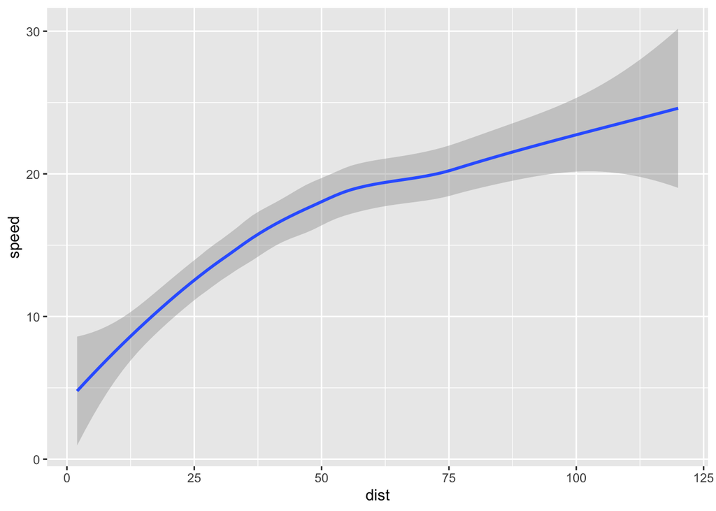

```r
ggplot(data = cars, aes(x= dist, y = speed)) +
  geom_smooth()
```

### Test 83 Ramsey RESET Test

```r
resettest(car_model)
```

```
##
##  RESET test
##
## data:  car_model
## RESET = 1.5554, df1 = 2, df2 = 46, p-value = 0.222
```

According to the result, we can find that p-value is larger than the critical value. Therefore, we can not reject the null hypothesis that this model is a linear model.

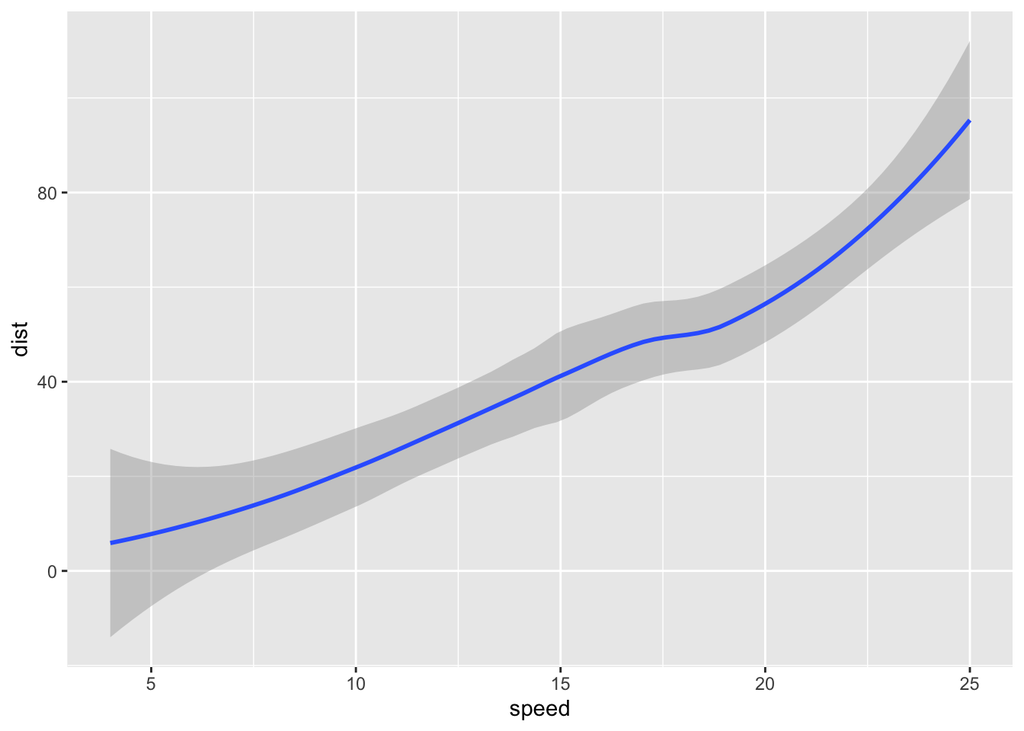

```r
ggplot(data = cars, aes(y = dist, x = speed)) +
  geom_smooth()
```

The Harvey-Collier test is sensitive to the **order of the data**. It works by calculating “recursive residuals” by adding one data point at a time. For this to work correctly, the data must be ordered by the predictor variable (`x`).

## Time Series Unit Root Tests (Test 85-91)

In simple terms, a time series with a **unit root** is **non-stationary**. This means its statistical properties (like its mean and variance) are not constant over time. It often wanders unpredictably up or down and is sometimes called a “random walk.”

### Test 85 Augmented Dickey-Fuller (ADF) Test

Question the test addresses:

**Does the data contain a unit root?**

We will use the data from Nile river.

```r
library(tseries)
adf.test(Nile)
```

```
##
##  Augmented Dickey-Fuller Test
##
## data:  Nile
## Dickey-Fuller = -3.3657, Lag order = 4, p-value = 0.0642
## alternative hypothesis: stationary
```

According to the result, we can find that the p-value is larger than the critical value. Therefore, we can not reject the null hypothesis that Nile river data is non-stationary.

### Test 86 Phillips-Perron Test

```r
pp.test(Nile)
```

```
##
##  Phillips-Perron Unit Root Test
##
## data:  Nile
## Dickey-Fuller Z(alpha) = -64.501, Truncation lag parameter = 3, p-value
## = 0.01
## alternative hypothesis: stationary
```

According to the result, we can find that the p-value is smaller than the critical value. Therefore, we can reject the null hypothesis that Nile river data is non-stationary.

This happens because they use different methods to handle the complex serial correlation in the time series. The ADF test adds lagged terms to the regression, while the PP test makes a non-parametric correction. Neither method is universally “better,” and when the results are borderline like this (0.064 is very close to 0.05), it’s common for them to disagree. An experienced analyst seeing this would conclude that the evidence is ambiguous and might investigate further.

### Test 87 Phillips-Ouliaris Test

Question the test addresses:

**Is the sample of multivariate observations cointegrated?**

To use this test:

- linear regression residual series are weakly dependent and heterogeneously distributed

We will use the `EuStockMarkets` dataset.

```r
po.test(diff(log(EuStockMarkets),1), demean = TRUE)
```

```
##
##  Phillips-Ouliaris Cointegration Test
##
## data:  diff(log(EuStockMarkets), 1)
## Phillips-Ouliaris demeaned = -1890.5, Truncation lag parameter = 18,
## p-value = 0.01
```

According to the result, we can find that the p-value is smaller than the critical value. Therefore, we can reject the null hypothesis that there is no cointegration in the EuStockMarkets dataset.

### Test 88 Kwiatkowski-Phillips-Schmidt-Shin Test

Question the test addresses:

**Is a sample of timeseries observations stationary around a deterministic trend?**

This test flips the null hypothesis in test 85 and test 86. The null hypothesis is that the timeseries is stationary.

```r
kpss.test(Nile, null = "Level")
```

```
##
##  KPSS Test for Level Stationarity
##
## data:  Nile
## KPSS Level = 0.96543, Truncation lag parameter = 4, p-value = 0.01
```

According to the result, we can find that the p-value is smaller than the critical value. Therefore, we can reject the null hypothesis that Nile river data is stationary.

### Test 89 Elliott, Rothenberg & Stock Test

Question the test addresses:

**Does the data contain a unit root?**

To use this test:

- efficient unit root test
- higher power than Test 85 Augmented Dickey-Fuller (ADF) Test and Test 86 Phillips-Perron Test

We can use this test to figure out the opposite result between test 85 and test 86 in Nile river. We also need the `urca` package. Type can be DF-GLS or P-test

```r
if (!require("urca")){
  install.packages("urca")
  library(urca)
}
summary(ur.ers(Nile, type = "DF-GLS", model = "trend", lag.max=4))
```

```
##
## ###############################################
## # Elliot, Rothenberg and Stock Unit Root Test #
## ###############################################
##
## Test of type DF-GLS
## detrending of series with intercept and trend
##
##
## Call:
## lm(formula = dfgls.form, data = data.dfgls)
##
## Residuals:
##     Min      1Q  Median      3Q     Max
## -404.09  -96.99  -10.17   93.36  312.14
##
## Coefficients:
##              Estimate Std. Error t value Pr(>|t|)
## yd.lag       -0.46763    0.14502  -3.225  0.00176 **
## yd.diff.lag1 -0.19020    0.14554  -1.307  0.19459
## yd.diff.lag2 -0.08078    0.13789  -0.586  0.55948
## yd.diff.lag3 -0.01036    0.12568  -0.082  0.93446
## yd.diff.lag4 -0.05392    0.10479  -0.515  0.60815
## ---
## Signif. codes:  0 '***' 0.001 '**' 0.01 '*' 0.05 '.' 0.1 ' ' 1
##
## Residual standard error: 142.2 on 90 degrees of freedom
## Multiple R-squared:  0.3178, Adjusted R-squared:  0.2799
## F-statistic: 8.385 on 5 and 90 DF,  p-value: 1.526e-06
##
##
## Value of test-statistic is: -3.2246
##
## Critical values of DF-GLS are:
##                  1pct  5pct 10pct
## critical values -3.46 -2.93 -2.64
```

According to the result, we can find that we can reject the null hypothesis at 5% significance level but can not reject the null hypothesis at 1% significance level. Therefore, the Nile dataset is stationary at the 5% significance level.

### Test 90 Schmidt-Phillips Test

We will use the `sunspots` dataset, which contained the monthly mean relative sunspot numbers from 1749 to 1983. We still need the package `urca`.

```r
summary(ur.sp(sunspots, type=
"tau"
, pol.deg=1, signif=0.05))
```

```
##
## ###################################
## # Schmidt-Phillips Unit Root Test #
## ###################################
##
##
## Call:
## lm(formula = sp.data)
##
## Residuals:
##     Min      1Q  Median      3Q     Max
## -65.795  -8.855  -1.505   8.030 102.129
##
## Coefficients:
##              Estimate Std. Error t value Pr(>|t|)
## (Intercept) 3.1674276  0.6991430    4.53 6.13e-06 ***
## y.lagged    0.9197909  0.0073972  124.34  < 2e-16 ***
## trend.exp1  0.0006636  0.0003949    1.68    0.093 .
## ---
## Signif. codes:  0 '***' 0.001 '**' 0.01 '*' 0.05 '.' 0.1 ' ' 1
##
## Residual standard error: 16.85 on 2816 degrees of freedom
## Multiple R-squared:  0.8497, Adjusted R-squared:  0.8496
## F-statistic:  7961 on 2 and 2816 DF,  p-value: < 2.2e-16
##
##
## Value of test-statistic is: -8.3987
## Critical value for a significance level of 0.05
## is: -3.02
```

According to the result, we can find that the p-value is smaller than the critical value. Therefore, we can reject the null hypothesis that there is a unit root in the timeseries.

### Test 91 Zivot and Andrews Test

Question the test addresses:

**Does the data with an expected structural break contain a unit root?**

```r
summary(ur.za(sunspots, model = "both", lag = 3))
```

```
##
## ################################
## # Zivot-Andrews Unit Root Test #
## ################################
##
##
## Call:
## lm(formula = testmat)
##
## Residuals:
##     Min      1Q  Median      3Q     Max
## -68.803  -8.381  -1.299   7.309  97.615
##
## Coefficients:
##              Estimate Std. Error t value Pr(>|t|)
## (Intercept)  1.131566   1.470660   0.769   0.4417
## y.l1         0.954095   0.007506 127.115  < 2e-16 ***
## trend        0.007247   0.005091   1.423   0.1547
## y.dl1       -0.362708   0.019217 -18.874  < 2e-16 ***
## y.dl2       -0.237927   0.019700 -12.078  < 2e-16 ***
## y.dl3       -0.134095   0.018689  -7.175  9.2e-13 ***
## du          -3.664648   1.620009  -2.262   0.0238 *
## dt          -0.006244   0.005097  -1.225   0.2206
## ---
## Signif. codes:  0 '***' 0.001 '**' 0.01 '*' 0.05 '.' 0.1 ' ' 1
##
## Residual standard error: 15.79 on 2808 degrees of freedom
##   (4 observations deleted due to missingness)
## Multiple R-squared:  0.8685, Adjusted R-squared:  0.8681
## F-statistic:  2649 on 7 and 2808 DF,  p-value: < 2.2e-16
##
##
## Teststatistic: -6.116
## Critical values: 0.01= -5.57 0.05= -5.08 0.1= -4.82
##
## Potential break point at position: 494
```

## Survival Analysis (Test 92-94)

### Test 92 Grambsch-Therneau Test of Proportionality

Question the test addresses:

**Is the assumption of proportional hazards for a Cox regression model fit valid?**

The “proportional hazards” assumption means that the relative risk between groups is constant over time. For example, if we’re comparing a treatment group to a control group, the assumption means that if the treatment group is half as likely to have the “event” (e.g., relapse) in the first month, they are also half as likely in the second month, the third month, and so on.

We will use the `survival` package and the `lung` dataset in this package.

```r
if (!require("survival")){
  install.packages("survival")
  library(survival)
}

cox_model <- coxph(Surv(time, status) ~ sex, data = lung)

cox.zph(cox_model)
```

```
##        chisq df     p
## sex     2.86  1 0.091
## GLOBAL  2.86  1 0.091
```

According to the result, we can find that the global p-value is larger than the critical value. Therefore, we can not reject the null hypothesis that the proportional hazards assumption is valid.

### Test 93 Mantel-Haenszel Log-Rank Test

Question the test addresses:

**Are there statistically significant differences between two or more survival curves?**

It works by comparing the observed number of events (e.g., deaths or relapses) in each group at each time point to the number that would be expected if there were no difference between the groups.

```r
survdiff(Surv(time, status) ~ sex, data = lung)
```

```
## Call:
## survdiff(formula = Surv(time, status) ~ sex, data = lung)
##
##         N Observed Expected (O-E)^2/E (O-E)^2/V
## sex=1 138      112     91.6      4.55      10.3
## sex=2  90       53     73.4      5.68      10.3
##
##  Chisq= 10.3  on 1 degrees of freedom, p= 0.001
```

According to the result, we can find that the p-value is smaller than the critical value. Therefore, we can reject the null hypothesis that there is no difference between the survival curves of the groups.

### Test 94 Peto and Peto Test

Question the test addresses:

**Are there statistically significant differences between two or more survival curves?**

To use this test:

- Alternative way to the log-rank test
- gives more weight to the events happen early in the timeline
- short-term survival differences between groups

Setting `rho = 1` tells the function to perform a Peto and Peto style test.

```r
survdiff(Surv(time, status) ~ sex, data = lung, rho = 1)
```

```
## Call:
## survdiff(formula = Surv(time, status) ~ sex, data = lung, rho = 1)
##
##         N Observed Expected (O-E)^2/E (O-E)^2/V
## sex=1 138     70.4     55.6      3.95      12.7
## sex=2  90     28.7     43.5      5.04      12.7
##
##  Chisq= 12.7  on 1 degrees of freedom, p= 4e-04
```

According to the result, we can find that the p-value is smaller than the critical value. Therefore, we can reject the null hypothesis that there is no difference between the survival curves of the groups, especially for the early results.

## Circular Data (Test 95-100)

Circular data represents directions (like compass headings), times of day, or seasons of the year.

These tests answer a similar question:

**Is the sample equally (uniformly) distributed with respect to angle?**

$H_0$: The data is uniformly distributed around the circle with no preferred direction.

### Test 95 Kuiper’s Test of Uniformity

```r
if (!require("circular")){
  install.packages("circular")
  library(circular)
}

turtles_circular <- circular(turtles, units = "degrees", template = "geographics")
kuiper.test(turtles_circular)
```

```
##
##        Kuiper's Test of Uniformity
##
## Test Statistic:  3.2115
## P-value < 0.01
##
```

According to the result, we can find that the p-value is smaller than the critical value. Therefore, we can reject the null hypothesis that there is no preferred nesting island for sea turtles.

### Test 96 Rao’s Spacing Test of Uniformity

To use this test:

- good all-purpose test for circular data
- It works by looking at the “spacings” or the arc lengths between each successive data point around the circle.

We can use the same circular object we created before.

```r
rao.spacing.test(turtles_circular)
```

```
##
##        Rao's Spacing Test of Uniformity
##
## Test Statistic = 246
## P-value < 0.001
##
```

According to the result, we can find that the p-value is smaller than the critical value. Therefore, we can reject the null hypothesis that there is no preferred nesting island for sea turtles.

### Test 97 Rayleigh Test of Uniformity

To use this test:

- calculating the mean vector of all directional data points
- if there is a particular direction, the mean vector can point in that direction

```r
rayleigh.test(turtles_circular)
```

```
##
##        Rayleigh Test of Uniformity
##        General Unimodal Alternative
##
## Test Statistic:  0.8301
## P-value:  0
```

According to the result, we can find that the p-value is smaller than the critical value. Therefore, we can reject the null hypothesis that there is no preferred nesting island for sea turtles.

Now we can see the mean vector through this way:

```r
mean.circular(turtles_circular)
```

```
## Circular Data:
## Type = angles
## Units = degrees
## Template = geographics
## Modulo = asis
## Zero = 1.570796
## Rotation = clock
## [1] -16.0904
```

```r
rho.circular(turtles_circular)
```

```
## [1] 0.8300967
```

### Test 98 Watson’s Goodness of Fit Test

Question the test addresses:

**Is the sample uniformly distributed or from the Von Mises distribution?**

The **Von Mises** distribution is often called the “normal distribution for circular data.” It describes data that is clustered around a single mean direction.

```r
watson.test(turtles_circular, dist = "uniform")
```

```
##
##        Watson's Test for Circular Uniformity
##
## Test Statistic: 0.8406
## P-value < 0.01
##
```

According to the result, we can find that the p-value is smaller than the critical value. Therefore, we can reject the null hypothesis that there is no preferred nesting island for sea turtles.

A standard Von Mises Distribution looks like:

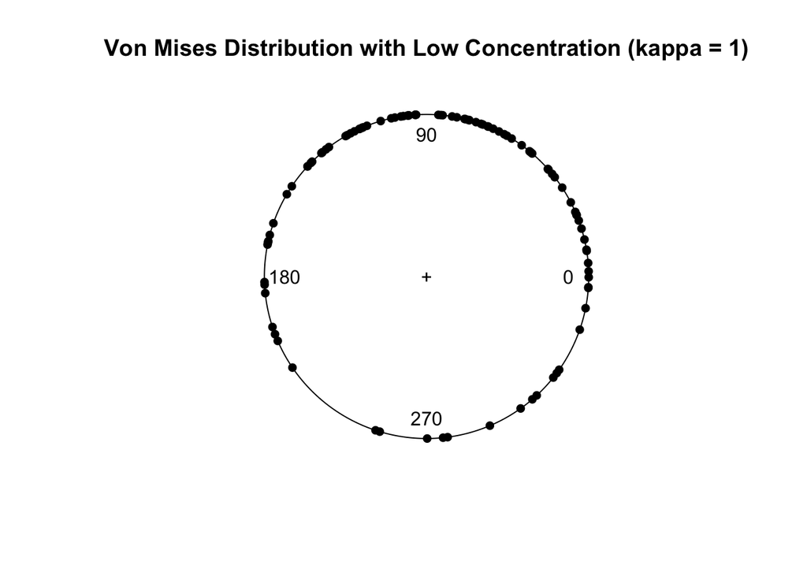

```r
set.seed(123)
spread_out_data <- rvonmises(n = 100, mu = circular(90, units = "degrees"), kappa = 1)
plot(spread_out_data, main = "Von Mises Distribution with Low Concentration (kappa = 1)")
```

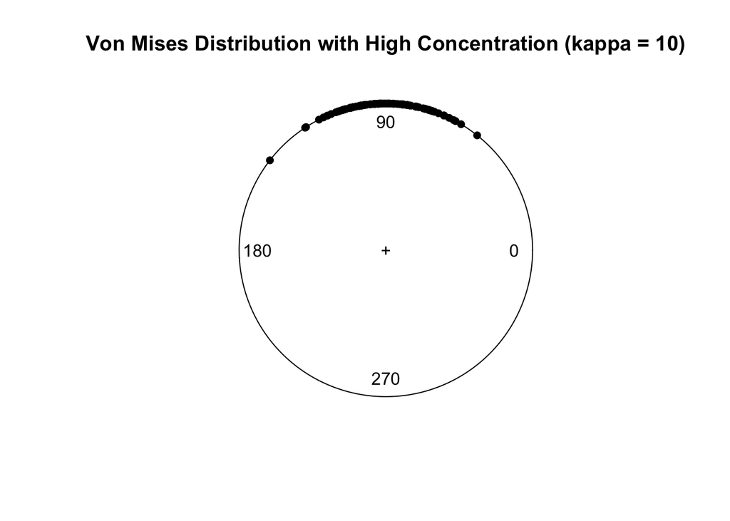

```r
concentrated_data <- rvonmises(n = 100, mu = circular(90, units = "degrees"), kappa = 10)
plot(concentrated_data, main = "Von Mises Distribution with High Concentration (kappa = 10)")
```

**Kappa** (kappa) is the key parameter that controls the **concentration** or spread of a Von Mises distribution.

### Test 99 Watson’s Two-Sample Test of Homogeneity

Question the test addresses:

**Do two independent samples of circular data come from the same distribution?**

This is the circular data version of Test 72 Two sample K-S Test.

We will create two samples with different levels of concentration.

```r
set.seed(456)

group1_directions<- rvonmises(n = 30, mu = circular(90, units = "degrees"), kappa = 8)

group2_directions<- rvonmises(n = 30, mu = circular(180, units = "degrees"), kappa = 2)
```

```r
watson.two.test(group1_directions, group2_directions)
```

```
##
##       Watson's Two-Sample Test of Homogeneity
##
## Test Statistic: 1.1101
## P-value < 0.001
##
```

According to the result, we can find that p-value is smaller than the critical value. Therefore, we can reject the null hypothesis that these two groups are drawn from the same distribution.

### Test 100 Rao’s Test for Homogeneity

To use this test:

- compare the mean direction and dispersion
- two or more samples

We will use our same samples created in test 99 to see whether they have the same mean direction and dispersion.

```r
rao.test(group1_directions, group2_directions)
```

```
##
## Rao's Tests for Homogeneity
##
##        Test for Equality of Polar Vectors:
##
## Test Statistic = 0.3669
## Degrees of Freedom = 1
## P-value of test = 0.5447
##
##        Test for Equality of Dispersions:
##
## Test Statistic = 4.7978
## Degrees of Freedom = 1
## P-value of test = 0.0285
##
```

According to the result, we can find that the p-value of the mean vector is larger than the critical value but the p-value of the dispersion is smaller than the critical value. Therefore, we can not reject the null hypothesis that our two groups of samples have the same mean direction but we can reject the null hypothesis that our two groups of samples have the same dispersion.

Now, we have a look on the results.

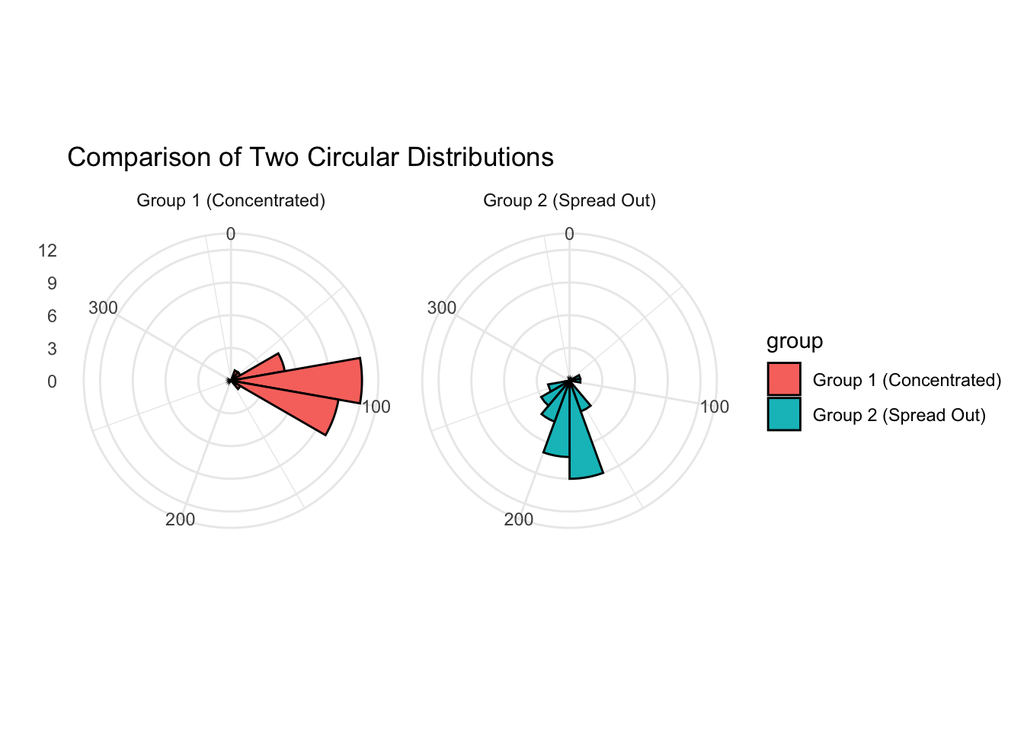

```r
plot_df <- data.frame(
  direction = c(as.numeric(group1_directions), as.numeric(group2_directions)),
  group = c(rep("Group 1 (Concentrated)", 30), rep("Group 2 (Spread Out)", 30))
)

ggplot(plot_df, aes(x = direction, fill = group)) +
  geom_histogram(breaks = seq(0, 360, by = 20), color = "black") +
  coord_polar() + # This is the magic function that makes it circular
  facet_wrap(~ group) + # This creates two separate plots for easy comparison
  labs(title = "Comparison of Two Circular Distributions", x = "", y = "") +
  theme_minimal()
```

Lewis, Nancy D., Nigel Da Costa Lewis, and N. D. Lewis. 2013. *100 Statistical Tests in r: What to Choose, How to Easily Calculate, with over 300 Illustrations and Examples*. Heather Hills Press.